# Health Care Demand - Australia

## Project’s Aim

The project’s aim is to analyze the factors influencing the `dvisits` (in the datset the variable is `doctorco`) variable in the *Health Care Australia* dataset. Such variable represents the *number of consultations with a doctor or specialist in the past 2 weeks*. We start by doing an exploratory data analysis that will allow us to better understand the dataset, which will be followed by a selection of statistical models. We will end with the comparison and the interpretation of selected models.

## Data Pre-Processing

[output not shown]

[output not shown]

```r
load("HealthCareAustralia.rda")
```

Let’s have an initial look at the data:

```r
head(ex3.health)
```

|  | sex | age | agesq | income | levyplus | freepoor | freepera | illness | actdays | hscore | chcond1 | chcond2 | doctorco | nondocco | hospadmi | hospdays | medicine | prescrib | nonpresc | constant |
| --- | --- | --- | --- | --- | --- | --- | --- | --- | --- | --- | --- | --- | --- | --- | --- | --- | --- | --- | --- | --- |
| 1 | 1 | 0.19 | 0.0361 | 0.55 | 1 | 0 | 0 | 1 | 4 | 1 | 0 | 0 | 1 | 0 | 0 | 0 | 1 | 1 | 0 | 1 |
| 2 | 1 | 0.19 | 0.0361 | 0.45 | 1 | 0 | 0 | 1 | 2 | 1 | 0 | 0 | 1 | 0 | 0 | 0 | 2 | 1 | 1 | 1 |
| 3 | 0 | 0.19 | 0.0361 | 0.90 | 0 | 0 | 0 | 3 | 0 | 0 | 0 | 0 | 1 | 0 | 1 | 4 | 2 | 1 | 1 | 1 |
| 4 | 0 | 0.19 | 0.0361 | 0.15 | 0 | 0 | 0 | 1 | 0 | 0 | 0 | 0 | 1 | 0 | 0 | 0 | 0 | 0 | 0 | 1 |
| 5 | 0 | 0.19 | 0.0361 | 0.45 | 0 | 0 | 0 | 2 | 5 | 1 | 1 | 0 | 1 | 0 | 0 | 0 | 3 | 1 | 2 | 1 |
| 6 | 1 | 0.19 | 0.0361 | 0.35 | 0 | 0 | 0 | 5 | 1 | 9 | 1 | 0 | 1 | 0 | 0 | 0 | 1 | 1 | 0 | 1 |

```r
str(ex3.health)
```

```
## 'data.frame':    5190 obs. of  20 variables:
##  $ sex     : num  1 1 0 0 0 1 1 1 1 0 ...
##  $ age     : num  0.19 0.19 0.19 0.19 0.19 0.19 0.19 0.19 0.19 0.19 ...
##  $ agesq   : num  0.0361 0.0361 0.0361 0.0361 0.0361 0.0361 0.0361 0.0361 0.0361 0.0361 ...
##  $ income  : num  0.55 0.45 0.9 0.15 0.45 0.35 0.55 0.15 0.65 0.15 ...
##  $ levyplus: num  1 1 0 0 0 0 0 0 1 1 ...
##  $ freepoor: num  0 0 0 0 0 0 0 0 0 0 ...
##  $ freepera: num  0 0 0 0 0 0 0 0 0 0 ...
##  $ illness : num  1 1 3 1 2 5 4 3 2 1 ...
##  $ actdays : num  4 2 0 0 5 1 0 0 0 0 ...
##  $ hscore  : num  1 1 0 0 1 9 2 6 5 0 ...
##  $ chcond1 : num  0 0 0 0 1 1 0 0 0 0 ...
##  $ chcond2 : num  0 0 0 0 0 0 0 0 0 0 ...
##  $ doctorco: num  1 1 1 1 1 1 1 1 1 1 ...
##  $ nondocco: num  0 0 0 0 0 0 0 0 0 0 ...
##  $ hospadmi: num  0 0 1 0 0 0 0 0 0 0 ...
##  $ hospdays: num  0 0 4 0 0 0 0 0 0 0 ...
##  $ medicine: num  1 2 2 0 3 1 0 1 1 1 ...
##  $ prescrib: num  1 1 1 0 1 1 0 1 0 1 ...
##  $ nonpresc: num  0 1 1 0 2 0 0 0 1 0 ...
##  $ constant: num  1 1 1 1 1 1 1 1 1 1 ...
```

```r
summary(ex3.health)
```

```
##       sex              age             agesq            income
##  Min.   :0.0000   Min.   :0.1900   Min.   :0.0361   Min.   :0.0000
##  1st Qu.:0.0000   1st Qu.:0.2200   1st Qu.:0.0484   1st Qu.:0.2500
##  Median :1.0000   Median :0.3200   Median :0.1024   Median :0.5500
##  Mean   :0.5206   Mean   :0.4064   Mean   :0.2071   Mean   :0.5832
##  3rd Qu.:1.0000   3rd Qu.:0.6200   3rd Qu.:0.3844   3rd Qu.:0.9000
##  Max.   :1.0000   Max.   :0.7200   Max.   :0.5184   Max.   :1.5000
##     levyplus         freepoor          freepera         illness
##  Min.   :0.0000   Min.   :0.00000   Min.   :0.0000   Min.   :0.000
##  1st Qu.:0.0000   1st Qu.:0.00000   1st Qu.:0.0000   1st Qu.:0.000
##  Median :0.0000   Median :0.00000   Median :0.0000   Median :1.000
##  Mean   :0.4428   Mean   :0.04277   Mean   :0.2102   Mean   :1.432
##  3rd Qu.:1.0000   3rd Qu.:0.00000   3rd Qu.:0.0000   3rd Qu.:2.000
##  Max.   :1.0000   Max.   :1.00000   Max.   :1.0000   Max.   :5.000
##     actdays            hscore          chcond1          chcond2
##  Min.   : 0.0000   Min.   : 0.000   Min.   :0.0000   Min.   :0.0000
##  1st Qu.: 0.0000   1st Qu.: 0.000   1st Qu.:0.0000   1st Qu.:0.0000
##  Median : 0.0000   Median : 0.000   Median :0.0000   Median :0.0000
##  Mean   : 0.8618   Mean   : 1.218   Mean   :0.4031   Mean   :0.1166
##  3rd Qu.: 0.0000   3rd Qu.: 2.000   3rd Qu.:1.0000   3rd Qu.:0.0000
##  Max.   :14.0000   Max.   :12.000   Max.   :1.0000   Max.   :1.0000
##     doctorco         nondocco          hospadmi         hospdays
##  Min.   :0.0000   Min.   : 0.0000   Min.   :0.0000   Min.   : 0.000
##  1st Qu.:0.0000   1st Qu.: 0.0000   1st Qu.:0.0000   1st Qu.: 0.000
##  Median :0.0000   Median : 0.0000   Median :0.0000   Median : 0.000
##  Mean   :0.3017   Mean   : 0.2146   Mean   :0.1736   Mean   : 1.334
##  3rd Qu.:0.0000   3rd Qu.: 0.0000   3rd Qu.:0.0000   3rd Qu.: 0.000
##  Max.   :9.0000   Max.   :11.0000   Max.   :5.0000   Max.   :80.000
##     medicine        prescrib         nonpresc         constant
##  Min.   :0.000   Min.   :0.0000   Min.   :0.0000   Min.   :1
##  1st Qu.:0.000   1st Qu.:0.0000   1st Qu.:0.0000   1st Qu.:1
##  Median :1.000   Median :0.0000   Median :0.0000   Median :1
##  Mean   :1.218   Mean   :0.8626   Mean   :0.3557   Mean   :1
##  3rd Qu.:2.000   3rd Qu.:1.0000   3rd Qu.:1.0000   3rd Qu.:1
##  Max.   :8.000   Max.   :8.0000   Max.   :8.0000   Max.   :1
```

We remove the column of constants

```r
ex3.health = ex3.health[,-20]
```

There are no missing (i.e. `na`) values, as we can see by executing the following command:

```r
sapply(ex3.health, function(x) sum(is.na(x)))
```

```
##      sex      age    agesq   income levyplus freepoor freepera  illness
##        0        0        0        0        0        0        0        0
##  actdays   hscore  chcond1  chcond2 doctorco nondocco hospadmi hospdays
##        0        0        0        0        0        0        0        0
## medicine prescrib nonpresc
##        0        0        0
```

Then we check if we can combine `levyplus`, `freepor` and `freepera` into a single variable, since they represent different kinds of insurance. We check the row sums of the matrix with columns such variables and make sure that all of them equal to either $1$ or $0$. We also check that the sum of ones in the list of rowSums equals the sum of ones of the three variables.

```r
table(ex3.health$levyplus)
```

```
##
##    0    1
## 2892 2298
```

```r
table(ex3.health$freepoor)
```

```
##
##    0    1
## 4968  222
```

```r
table(ex3.health$freepera)
```

```
##
##    0    1
## 4099 1091
```

```r
a = rowSums(ex3.health[c('freepoor','freepera','levyplus')])
table(a)
```

```
## a
##    0    1
## 1579 3611
```

```r
print(2298 + 222 + 1091)
```

```
## [1] 3611
```

We can now merge them in a single variable called `insurance`. Note: to avoid linear dependence we must now drop the old variables from the dataframe.

```r
ex3.health$insurance <- rep(0, length(ex3.health$levyplus))
ex3.health$insurance <- ifelse(ex3.health$levyplus == 1, 1, ex3.health$insurance)
ex3.health$insurance <- ifelse(ex3.health$freepoor == 1, 2, ex3.health$insurance)
ex3.health$insurance <- ifelse(ex3.health$freepera == 1, 3, ex3.health$insurance)

ex3.health$insurance <- factor(ex3.health$insurance, levels = c(0,1,2,3), labels = c('No', 'Private', 'Freepoor', 'Freepera'))

df <- subset(ex3.health, select = -c(levyplus, freepoor,freepera))
```

We do the same procedure for variables `chcond1` and `chcond2` since their description makes us believe they, too, are mutually exclusive.

```r
table(df$chcond1)
```

```
##
##    0    1
## 3098 2092
```

```r
table(df$chcond2)
```

```
##
##    0    1
## 4585  605
```

```r
b = rowSums(df[c('chcond1','chcond2')])
table(b)
```

```
## b
##    0    1
## 2493 2697
```

```r
print(2092 + 605)
```

```
## [1] 2697
```

```r
df$chcond <- rep(0, length(df$insurance))
df$chcond <- ifelse(df$chcond1 == 1, 1, df$chcond)
df$chcond <- ifelse(df$chcond2 == 1, 2, df$chcond)

df$chcond <- factor(df$chcond, levels = c(0,1,2), labels = c('No', 'Not-limited', 'Limited'))
df <- subset(df, select = -c(chcond1, chcond2))
```

Another thing we observed in the description of the data is that the sum of `prescrib` and `nonprescr` is saved into `medicine`, which means we can drop the `medicine` variable, too.

```r
check <- df$prescrib + df$nonpresc == df$medicine
all_correct <- all(check)

if(all_correct){
  print("We can drop medicine")
  df <- subset(df, select = -c(medicine))
} else {
  print("medicine cannot be dropped")
}
```

```
## [1] "We can drop medicine"
```

The last variable we remove from the dataset is `agesq` since it can be easily calculated if needed.

```r
df <- subset(df, select = -c(agesq))
```

Lastly, let’s convert sex into a factor

```r
df$sex <- factor(df$sex, levels = c(0, 1), labels = c("Male", "Female"))
```

## Exploratory Data Analysis

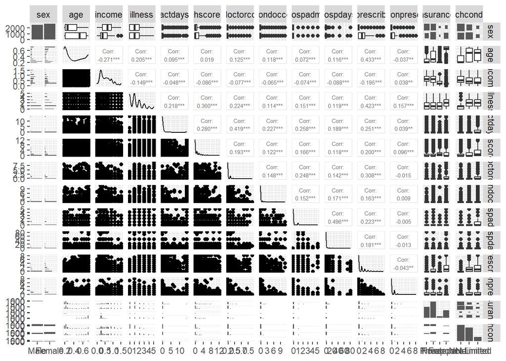

```r
ggpairs(df, upper = list(continuous = wrap("cor", size = 2)))
```

Let’s more closely explore the `doctorco` variable. The first thing that comes to mind is the asymmetry and imbalance of the data. More than half the observations are $0$. If we also calculate the imbalance ratio IR we obtain $IR=\frac{|\text{majority class}|}{|\text{rest}|}=\frac{4141}{1049}=3.947569$

```r
length(df$doctorco[df$doctorco==0])
```

```
## [1] 4141
```

```r
length(df$doctorco[df$doctorco!=0])
```

```
## [1] 1049
```

```r
length(df$doctorco[df$doctorco==0])/length(df$doctorco[df$doctorco!=0])
```

```
## [1] 3.947569
```

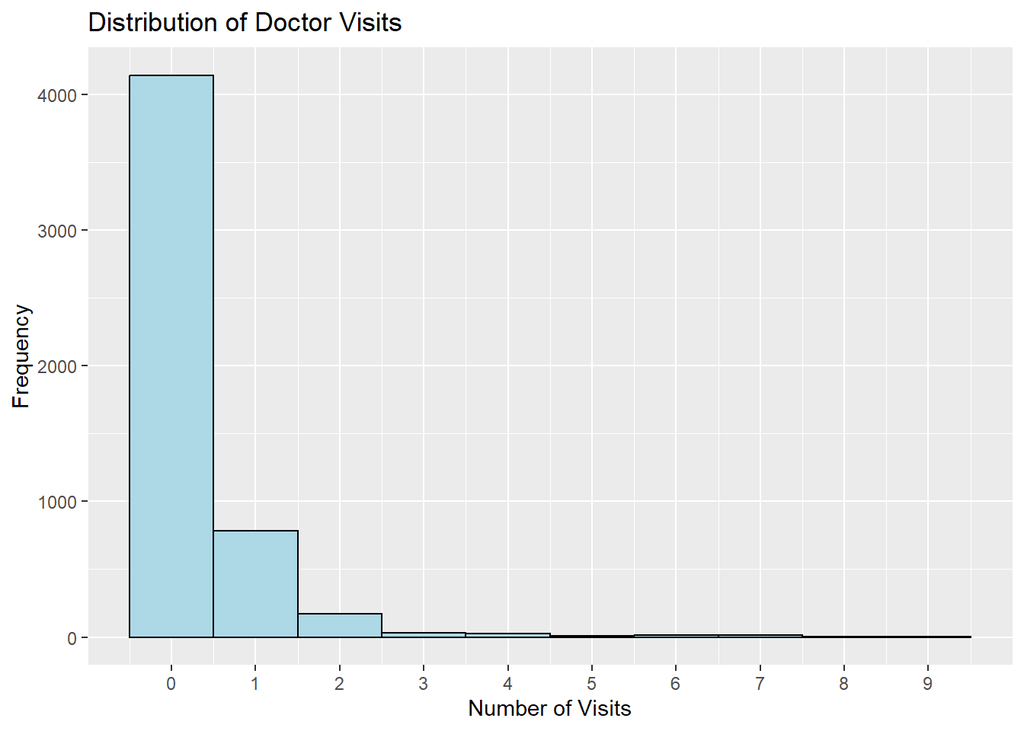

```r
ggplot(df, aes(x = doctorco)) +
  geom_histogram(bins = 10, color = "black", fill = "lightblue") +
  labs(title = "Distribution of Doctor Visits", x = "Number of Visits", y = "Frequency")+
  scale_x_continuous(breaks = c(0, 1, 2, 3, 4, 5,6,7,8,9))
```

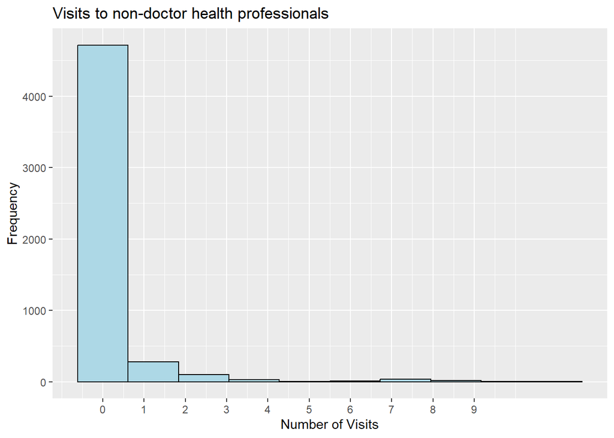

```r
ggplot(df, aes(x = nondocco)) +
  geom_histogram(bins = 10, color = "black", fill = "lightblue") +
  labs(title = "Visits to non-doctor health professionals", x = "Number of Visits", y = "Frequency")+
  scale_x_continuous(breaks = c(0, 1, 2, 3, 4, 5,6,7,8,9))
```

Following are the distributions of possible explanatory variables.

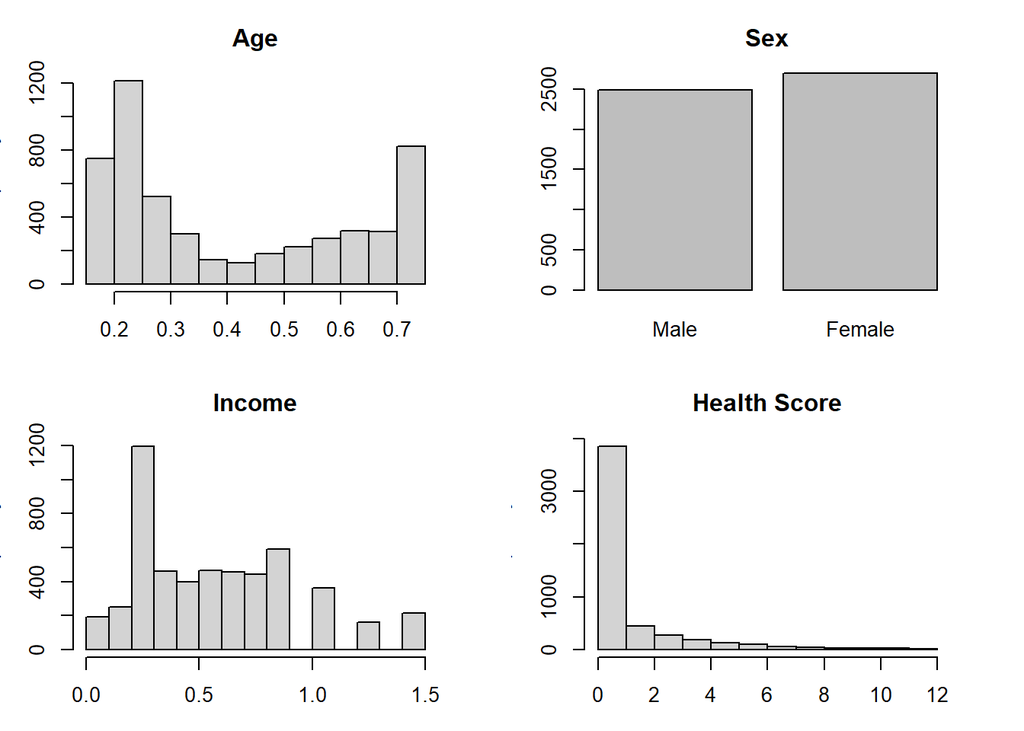

```r
par(mfrow=c(2,2), mai=c(0.5,0.5,0.5,0.5))
hist(df$age, main="Age", xlab="Age")
barplot(table(df$sex), main="Sex", xlab="Sex")
hist(df$income, main="Income", xlab="Income")
hist(df$hscore, main="Health Score", xlab="Health Score")
```

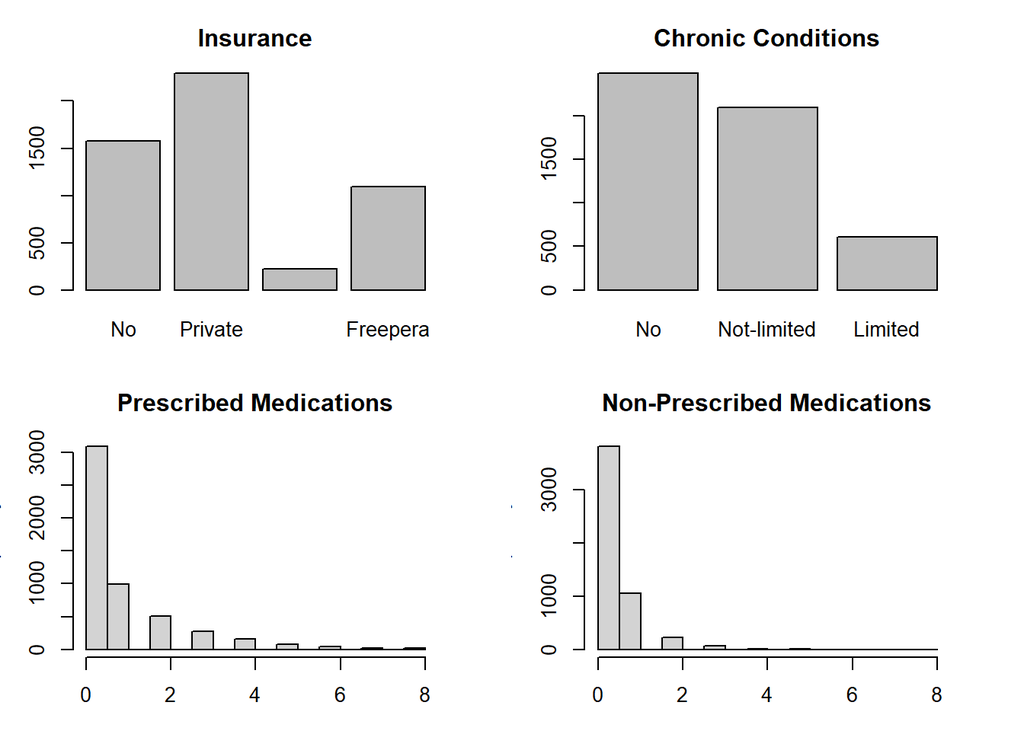

```r
barplot(table(df$insurance), main = 'Insurance')
barplot(table(df$chcond), main = 'Chronic Conditions')
hist(df$prescrib, main="Prescribed Medications")
hist(df$nonpresc, main="Non-Prescribed Medications")
```

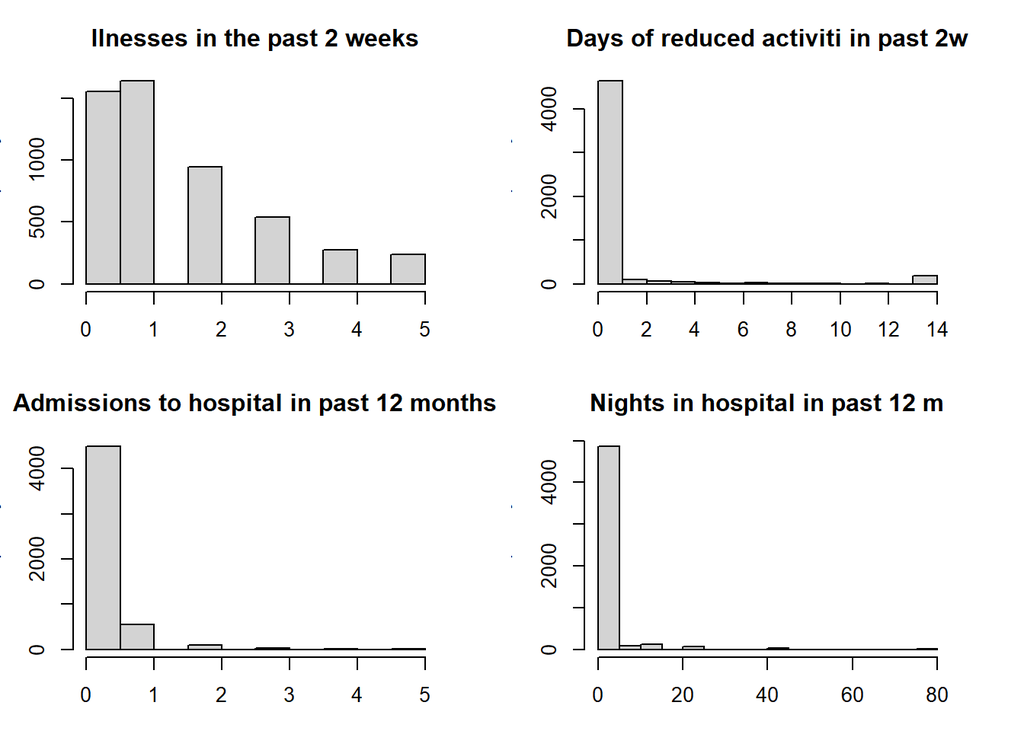

```r
hist(df$illness, main="Ilnesses in the past 2 weeks")
hist(df$actdays, main="Days of reduced activiti in past 2w")
hist(df$hospadmi, main="Admissions to hospital in past 12 months")
hist(df$hospdays, main="Nights in hospital in past 12 m")
```

```r
par(mfrow=c(1,1))
```

### Correlation Analysis

We now explore the correlation between the *numerical* variables. In the below plot we observe that no variable has a significantly strong correlation with `doctorco`. Nonetheless, the “strongest” we find are: `actdays`, `illness`, `hospadmi`, `prescrib` and maybe `hscore`.

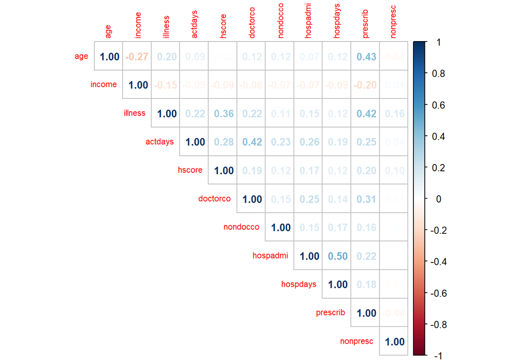

```r
cor_matrix <- cor(df[, sapply(df, is.numeric)])
corrplot(cor_matrix, method = "number", type = "upper", tl.cex = .7,
         cl.cex = 0.8, number.cex = 0.85)
```

With regards to the categorical variables, we can boxplot `doctorco` conditional to such variables.

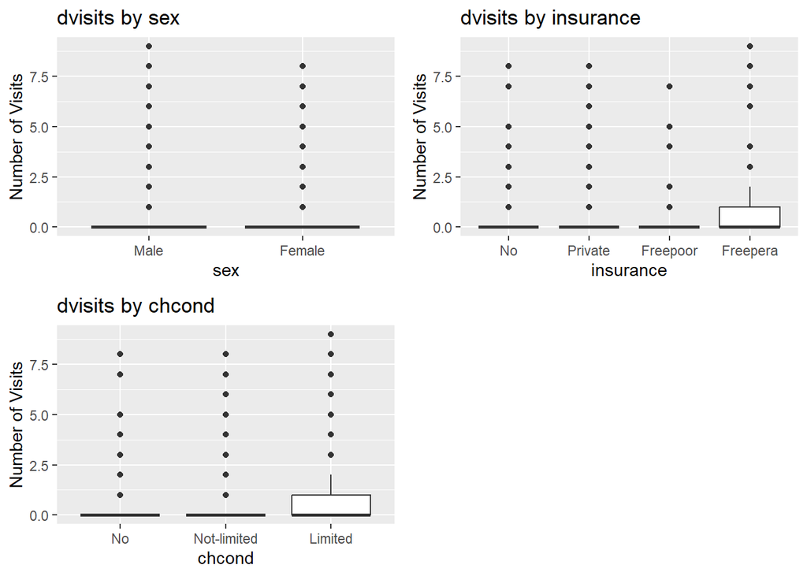

```r
p1 <- ggplot(df, aes(x = sex, y = doctorco)) +
  geom_boxplot() +
  labs(title = "dvisits by sex", x = "sex", y = "Number of Visits")

p2 <- ggplot(df, aes(x = insurance, y = doctorco)) +
  geom_boxplot() +
  labs(title = "dvisits by insurance", y = "Number of Visits")

p3 <- ggplot(df, aes(x = chcond, y = doctorco)) +
  geom_boxplot() +
  labs(title = "dvisits by chcond", y = "Number of Visits")

grid.arrange(p1,p2,p3, ncol=2)
```

Since the visual inspection doesn’t allow is to say anything, we could try some other tests.For `sex`, we fit a logistic model. For `insurance` and `chcond` we do the analysis of variance because they have more that two levels. We see below their significance:

- A lower residual deviance compared to null deviance suggests that the model with doctorco provides a better fit.
- Both for the aov of `doctorco ~ insurance` and of `doctorco ~ chcond`, given the small p-value, we can say that there are significant differences `doctorco` based on the categories of `insurance` and `chcond`.

```r
sex_model <- glm(sex ~ doctorco, family = binomial, data=df)
summary(sex_model)
```

```
##
## Call:
## glm(formula = sex ~ doctorco, family = binomial, data = df)
##
## Coefficients:
##             Estimate Std. Error z value Pr(>|z|)
## (Intercept)  0.01981    0.02989   0.663    0.508
## doctorco     0.21530    0.03920   5.492 3.96e-08 ***
## ---
## Signif. codes:  0 '***' 0.001 '**' 0.01 '*' 0.05 '.' 0.1 ' ' 1
##
## (Dispersion parameter for binomial family taken to be 1)
##
##     Null deviance: 7186.0  on 5189  degrees of freedom
## Residual deviance: 7152.4  on 5188  degrees of freedom
## AIC: 7156.4
##
## Number of Fisher Scoring iterations: 4
```

```r
print("-----------------------------------------------------------")
```

```
## [1] "-----------------------------------------------------------"
```

```r
insurance_model <- aov(doctorco ~ insurance, data=df)
summary(insurance_model)
```

```
##               Df Sum Sq Mean Sq F value   Pr(>F)
## insurance      3     45  15.100   24.02 1.97e-15 ***
## Residuals   5186   3260   0.629
## ---
## Signif. codes:  0 '***' 0.001 '**' 0.01 '*' 0.05 '.' 0.1 ' ' 1
```

```r
print("-----------------------------------------------------------")
```

```
## [1] "-----------------------------------------------------------"
```

```r
chcond_model <- aov(doctorco ~ chcond, data=df)
summary(chcond_model)
```

```
##               Df Sum Sq Mean Sq F value Pr(>F)
## chcond         2     89   44.61   71.94 <2e-16 ***
## Residuals   5187   3216    0.62
## ---
## Signif. codes:  0 '***' 0.001 '**' 0.01 '*' 0.05 '.' 0.1 ' ' 1
```

One last thing we should do before proceeding with the statistical modelling is to split the data into a training set and a test set. That way we can compare different methods.

```r
trainIndex <- createDataPartition(df$doctorco, p = 0.7, list = FALSE)

train_data <- df[trainIndex, ]
test_data <- df[-trainIndex, ]
```

## Selection and Comparison of Statistical Models

Let’s first try the simplest models: linear regression. We will fit

- one with all the variables without interaction,
- one with all the variables with interaction
- one with the “selected” variables

```r
model.full_noint <- lm(doctorco ~ ., data = train_data)
summary(model.full_noint)
```

```
##
## Call:
## lm(formula = doctorco ~ ., data = train_data)
##
## Residuals:
##     Min      1Q  Median      3Q     Max
## -2.7575 -0.2344 -0.1090 -0.0408  6.8940
##
## Coefficients:
##                    Estimate Std. Error t value Pr(>|t|)
## (Intercept)        0.125613   0.041018   3.062 0.002212 **
## sexFemale         -0.006450   0.024452  -0.264 0.791963
## age               -0.061771   0.076723  -0.805 0.420809
## income            -0.049394   0.035024  -1.410 0.158548
## illness            0.020705   0.009660   2.143 0.032150 *
## actdays            0.087229   0.004366  19.980  < 2e-16 ***
## hscore             0.020467   0.005806   3.525 0.000428 ***
## nondocco           0.034872   0.011839   2.945 0.003245 **
## hospadmi           0.163216   0.026223   6.224  5.4e-10 ***
## hospdays          -0.003156   0.001972  -1.600 0.109626
## prescrib           0.090711   0.010057   9.020  < 2e-16 ***
## nonpresc          -0.049037   0.015569  -3.150 0.001648 **
## insurancePrivate   0.020288   0.027926   0.727 0.467569
## insuranceFreepoor -0.112371   0.059453  -1.890 0.058829 .
## insuranceFreepera  0.039383   0.042866   0.919 0.358290
## chcondNot-limited -0.003906   0.026777  -0.146 0.884043
## chcondLimited     -0.037706   0.041055  -0.918 0.358460
## ---
## Signif. codes:  0 '***' 0.001 '**' 0.01 '*' 0.05 '.' 0.1 ' ' 1
##
## Residual standard error: 0.6681 on 3616 degrees of freedom
## Multiple R-squared:  0.2377, Adjusted R-squared:  0.2343
## F-statistic: 70.47 on 16 and 3616 DF,  p-value: < 2.2e-16
```

```r
model.full_int <- lm(doctorco ~ (.)^2, data = train_data)
summary(model.full_int)
```

```
##
## Call:
## lm(formula = doctorco ~ (.)^2, data = train_data)
##
## Residuals:
##     Min      1Q  Median      3Q     Max
## -3.9015 -0.2534 -0.1049  0.0078  6.4381
##
## Coefficients:
##                                       Estimate Std. Error t value Pr(>|t|)
## (Intercept)                         -1.955e-03  8.976e-02  -0.022 0.982622
## sexFemale                            4.511e-02  8.230e-02   0.548 0.583630
## age                                  5.401e-01  2.595e-01   2.081 0.037528 *
## income                              -1.725e-02  9.985e-02  -0.173 0.862837
## illness                              6.301e-02  3.761e-02   1.675 0.093928 .
## actdays                              1.903e-01  1.861e-02  10.224  < 2e-16 ***
## hscore                               2.618e-02  2.161e-02   1.212 0.225722
## nondocco                             1.250e-01  6.341e-02   1.972 0.048680 *
## hospadmi                             1.651e-01  1.131e-01   1.459 0.144580
## hospdays                            -4.843e-03  1.284e-02  -0.377 0.706084
## prescrib                             2.246e-01  5.645e-02   3.978 7.10e-05 ***
## nonpresc                            -2.948e-02  5.971e-02  -0.494 0.621615
## insurancePrivate                    -1.446e-01  9.309e-02  -1.554 0.120328
## insuranceFreepoor                    1.603e-02  1.919e-01   0.084 0.933436
## insuranceFreepera                   -1.011e-01  2.208e-01  -0.458 0.647124
## chcondNot-limited                   -1.592e-01  9.990e-02  -1.593 0.111199
## chcondLimited                       -3.822e-01  1.695e-01  -2.255 0.024216 *
## sexFemale:age                       -1.482e-01  1.682e-01  -0.881 0.378374
## sexFemale:income                    -4.392e-02  7.387e-02  -0.595 0.552178
## sexFemale:illness                    8.131e-04  2.097e-02   0.039 0.969070
## sexFemale:actdays                   -2.198e-02  9.969e-03  -2.204 0.027571 *
## sexFemale:hscore                    -1.202e-02  1.279e-02  -0.940 0.347420
## sexFemale:nondocco                  -6.306e-03  3.111e-02  -0.203 0.839393
## sexFemale:hospadmi                  -1.841e-01  5.974e-02  -3.082 0.002069 **
## sexFemale:hospdays                   4.532e-03  5.101e-03   0.888 0.374385
## sexFemale:prescrib                  -3.121e-02  2.278e-02  -1.370 0.170763
## sexFemale:nonpresc                   2.079e-02  3.576e-02   0.581 0.560973
## sexFemale:insurancePrivate           9.813e-02  5.904e-02   1.662 0.096564 .
## sexFemale:insuranceFreepoor          1.670e-01  1.290e-01   1.295 0.195291
## sexFemale:insuranceFreepera          4.059e-02  9.468e-02   0.429 0.668134
```

[output cut: 94 more lines]

```
## nonpresc:insuranceFreepera           9.784e-02  6.531e-02   1.498 0.134245
## nonpresc:chcondNot-limited          -3.611e-02  3.606e-02  -1.001 0.316727
## nonpresc:chcondLimited               1.942e-02  6.156e-02   0.315 0.752484
## insurancePrivate:chcondNot-limited  -1.548e-02  6.318e-02  -0.245 0.806474
## insuranceFreepoor:chcondNot-limited  2.171e-01  1.572e-01   1.381 0.167368
## insuranceFreepera:chcondNot-limited  1.422e-01  1.055e-01   1.348 0.177606
## insurancePrivate:chcondLimited       2.207e-01  1.097e-01   2.012 0.044249 *
## insuranceFreepoor:chcondLimited      2.747e-01  2.160e-01   1.272 0.203503
## insuranceFreepera:chcondLimited      5.243e-01  1.518e-01   3.453 0.000561 ***
## ---
## Signif. codes:  0 '***' 0.001 '**' 0.01 '*' 0.05 '.' 0.1 ' ' 1
##
## Residual standard error: 0.642 on 3500 degrees of freedom
## Multiple R-squared:  0.3186, Adjusted R-squared:  0.2929
## F-statistic:  12.4 on 132 and 3500 DF,  p-value: < 2.2e-16
```

```r
model.selected <- lm(doctorco ~ actdays + illness + hospadmi + prescrib + hscore + income + insurance, data=train_data)
summary(model.selected)
```

```
##
## Call:
## lm(formula = doctorco ~ actdays + illness + hospadmi + prescrib +
##     hscore + income + insurance, data = train_data)
##
## Residuals:
##     Min      1Q  Median      3Q     Max
## -2.7077 -0.2318 -0.1050 -0.0521  6.8698
##
## Coefficients:
##                    Estimate Std. Error t value Pr(>|t|)
## (Intercept)        0.093848   0.032235   2.911 0.003621 **
## actdays            0.088058   0.004304  20.458  < 2e-16 ***
## illness            0.014715   0.009282   1.585 0.112952
## hospadmi           0.148985   0.023438   6.357 2.32e-10 ***
## prescrib           0.091050   0.009446   9.639  < 2e-16 ***
## hscore             0.020158   0.005763   3.498 0.000474 ***
## income            -0.049518   0.033971  -1.458 0.145030
## insurancePrivate   0.012751   0.026629   0.479 0.632068
## insuranceFreepoor -0.110445   0.059434  -1.858 0.063211 .
## insuranceFreepera  0.023566   0.035866   0.657 0.511185
## ---
## Signif. codes:  0 '***' 0.001 '**' 0.01 '*' 0.05 '.' 0.1 ' ' 1
##
## Residual standard error: 0.6695 on 3623 degrees of freedom
## Multiple R-squared:  0.2331, Adjusted R-squared:  0.2312
## F-statistic: 122.3 on 9 and 3623 DF,  p-value: < 2.2e-16
```

Another thing that was noticeable from the nature of the variable of interest, i.e. `doctorco`, is that it is a counting variable. This makes us think that a glm poisson model may be adequate.

Let’s check for this:

```r
round(table(train_data$doctorco)/nrow(train_data), 6)
```

```
##
##        0        1        2        3        4        5        6        7
## 0.797963 0.151390 0.035233 0.005230 0.004129 0.001376 0.001652 0.001927
##        8        9
## 0.000826 0.000275
```

```r
cat(round(dpois(0:9, mean(train_data$doctorco)), 6))
```

```
## 0.745708 0.218807 0.032101 0.00314 0.00023 1.4e-05 1e-06 0 0 0
```

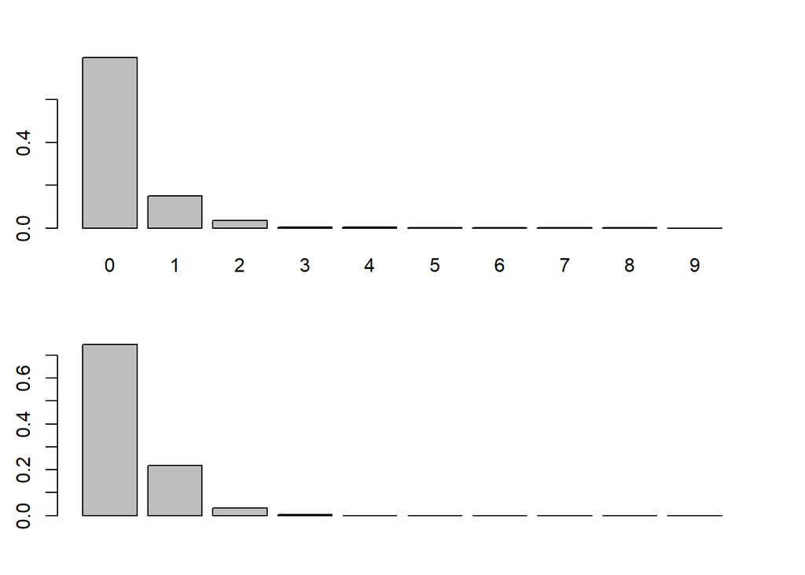

```r
par(mfrow=c(2,1), mai=c(0.5,0.5,0.5,0.5))
barplot(table(train_data$doctorco)/nrow(train_data))
barplot(dpois(0:9, mean(train_data$doctorco)))
```

```r
par(mfrow=c(1,1))
```

Let’s now fit such model.

```r
model.glm_poiss_noint <- glm(doctorco ~ . , family = poisson, data=train_data)
summary(model.glm_poiss_noint)
```

```
##
## Call:
## glm(formula = doctorco ~ ., family = poisson, data = train_data)
##
## Coefficients:
##                     Estimate Std. Error z value Pr(>|z|)
## (Intercept)       -1.8263846  0.1265422 -14.433  < 2e-16 ***
## sexFemale          0.0756850  0.0683842   1.107   0.2684
## age               -0.2307846  0.2147125  -1.075   0.2824
## income            -0.1836572  0.1062716  -1.728   0.0840 .
## illness            0.0939750  0.0240142   3.913 9.10e-05 ***
## actdays            0.1057998  0.0068746  15.390  < 2e-16 ***
## hscore             0.0333050  0.0124134   2.683   0.0073 **
## nondocco           0.0316034  0.0177472   1.781   0.0750 .
## hospadmi           0.1288845  0.0405899   3.175   0.0015 **
## hospdays          -0.0006648  0.0033395  -0.199   0.8422
## prescrib           0.1370110  0.0201376   6.804 1.02e-11 ***
## nonpresc          -0.1505271  0.0495799  -3.036   0.0024 **
## insurancePrivate   0.0831566  0.0889157   0.935   0.3497
## insuranceFreepoor -0.4642068  0.2220570  -2.090   0.0366 *
## insuranceFreepera  0.1005129  0.1142537   0.880   0.3790
## chcondNot-limited  0.1927484  0.0825287   2.336   0.0195 *
## chcondLimited      0.1003701  0.1042995   0.962   0.3359
## ---
## Signif. codes:  0 '***' 0.001 '**' 0.01 '*' 0.05 '.' 0.1 ' ' 1
##
## (Dispersion parameter for poisson family taken to be 1)
##
##     Null deviance: 3800.2  on 3632  degrees of freedom
## Residual deviance: 2892.1  on 3616  degrees of freedom
## AIC: 4548.3
##
## Number of Fisher Scoring iterations: 6
```

```r
model.glm_poiss_int <- glm(doctorco ~ (.)^2 , family = poisson, data=train_data)
summary(model.glm_poiss_int)
```

```
##
## Call:
## glm(formula = doctorco ~ (.)^2, family = poisson, data = train_data)
##
## Coefficients:
##                                       Estimate Std. Error z value Pr(>|z|)
## (Intercept)                         -2.559e+00  3.318e-01  -7.712 1.23e-14 ***
## sexFemale                            4.288e-01  2.828e-01   1.516 0.129454
## age                                  1.606e+00  8.240e-01   1.949 0.051252 .
## income                              -2.683e-01  3.697e-01  -0.726 0.467906
## illness                              4.193e-01  1.136e-01   3.693 0.000222 ***
## actdays                              2.487e-01  2.822e-02   8.814  < 2e-16 ***
## hscore                               7.049e-02  5.951e-02   1.184 0.236272
## nondocco                             2.444e-01  1.186e-01   2.060 0.039427 *
## hospadmi                             4.647e-01  2.640e-01   1.760 0.078337 .
## hospdays                            -2.142e-02  2.712e-02  -0.790 0.429639
## prescrib                             6.070e-01  1.353e-01   4.487 7.24e-06 ***
## nonpresc                            -1.099e-02  2.229e-01  -0.049 0.960684
## insurancePrivate                    -6.591e-01  3.629e-01  -1.816 0.069323 .
## insuranceFreepoor                   -8.603e-01  1.303e+00  -0.660 0.509168
## insuranceFreepera                   -5.991e-01  6.396e-01  -0.937 0.348936
## chcondNot-limited                   -7.236e-01  3.703e-01  -1.954 0.050702 .
## chcondLimited                       -1.279e+00  5.546e-01  -2.306 0.021094 *
## sexFemale:age                       -6.764e-01  5.338e-01  -1.267 0.205100
## sexFemale:income                    -2.004e-01  2.416e-01  -0.829 0.406917
## sexFemale:illness                   -6.224e-02  5.895e-02  -1.056 0.291094
## sexFemale:actdays                   -1.173e-02  1.589e-02  -0.738 0.460351
## sexFemale:hscore                    -4.096e-02  3.168e-02  -1.293 0.196065
## sexFemale:nondocco                   2.665e-02  6.074e-02   0.439 0.660762
## sexFemale:hospadmi                  -2.579e-01  1.123e-01  -2.298 0.021589 *
## sexFemale:hospdays                   5.393e-03  9.929e-03   0.543 0.587036
## sexFemale:prescrib                  -5.644e-03  4.759e-02  -0.119 0.905587
## sexFemale:nonpresc                  -1.852e-02  1.241e-01  -0.149 0.881420
## sexFemale:insurancePrivate           4.086e-01  2.060e-01   1.983 0.047330 *
## sexFemale:insuranceFreepoor          1.241e+00  7.546e-01   1.644 0.100171
## sexFemale:insuranceFreepera          1.779e-01  2.697e-01   0.660 0.509361
## sexFemale:chcondNot-limited          7.075e-02  1.931e-01   0.366 0.714144
## sexFemale:chcondLimited              2.626e-01  2.460e-01   1.067 0.285788
## age:income                          -2.068e+00  7.887e-01  -2.622 0.008739 **
## age:illness                         -1.279e-01  1.845e-01  -0.693 0.488190
```

[output cut: 94 more lines]

```
## insuranceFreepoor:chcondNot-limited  1.814e+00  8.115e-01   2.235 0.025402 *
## insuranceFreepera:chcondNot-limited  4.784e-01  3.341e-01   1.432 0.152194
## insurancePrivate:chcondLimited       8.103e-01  3.589e-01   2.258 0.023951 *
## insuranceFreepoor:chcondLimited      1.227e+00  1.064e+00   1.153 0.248994
## insuranceFreepera:chcondLimited      1.414e+00  4.542e-01   3.113 0.001850 **
## ---
## Signif. codes:  0 '***' 0.001 '**' 0.01 '*' 0.05 '.' 0.1 ' ' 1
##
## (Dispersion parameter for poisson family taken to be 1)
##
##     Null deviance: 3800.2  on 3632  degrees of freedom
## Residual deviance: 2552.4  on 3500  degrees of freedom
## AIC: 4440.7
##
## Number of Fisher Scoring iterations: 14
```

We may have the suspicion that the explanatory variables are correlated to the response in a non linear way, so let’s consider a Generalized Additive Model.

```r
model.gam <- gam(doctorco ~ s(income, k=10) + s(illness, k=6) + s(actdays) +
                 s(prescrib, k=9) + s(hospadmi, k=6) + hscore + insurance,
                 data = train_data , family = poisson())
summary(model.gam)
```

```
##
## Family: poisson
## Link function: log
##
## Formula:
## doctorco ~ s(income, k = 10) + s(illness, k = 6) + s(actdays) +
##     s(prescrib, k = 9) + s(hospadmi, k = 6) + hscore + insurance
##
## Parametric coefficients:
##                   Estimate Std. Error z value Pr(>|z|)
## (Intercept)       -1.73870    0.07392 -23.522  < 2e-16 ***
## hscore             0.03969    0.01192   3.330 0.000869 ***
## insurancePrivate   0.02269    0.08567   0.265 0.791105
## insuranceFreepoor -0.52328    0.22450  -2.331 0.019758 *
## insuranceFreepera  0.11114    0.10158   1.094 0.273898
## ---
## Signif. codes:  0 '***' 0.001 '**' 0.01 '*' 0.05 '.' 0.1 ' ' 1
##
## Approximate significance of smooth terms:
##               edf Ref.df  Chi.sq  p-value
## s(income)   1.824  2.291   7.709   0.0301 *
## s(illness)  3.687  4.330  40.524  < 2e-16 ***
## s(actdays)  6.111  7.160 400.275  < 2e-16 ***
## s(prescrib) 4.333  5.238 113.038  < 2e-16 ***
## s(hospadmi) 1.001  1.003  26.474 7.43e-07 ***
## ---
## Signif. codes:  0 '***' 0.001 '**' 0.01 '*' 0.05 '.' 0.1 ' ' 1
##
## R-sq.(adj) =  0.269   Deviance explained = 30.8%
## UBRE = -0.26443  Scale est. = 1         n = 3633
```

Our response variable has a very large number of zeros. This may have been caused because simply a person rarely visits the doctor or because the person goes to the doctor outside of the observation period of such variable, which is 2 weeks. That is why we will now consider zero-inflated poisson models.

```r
model.zip_noint <- zeroinfl(doctorco ~ . | ., data = train_data, dist = "poisson")
summary(model.zip_noint)
```

```
##
## Call:
## zeroinfl(formula = doctorco ~ . | ., data = train_data, dist = "poisson")
##
## Pearson residuals:
##     Min      1Q  Median      3Q     Max
## -1.9510 -0.4494 -0.2598 -0.1592 12.0561
##
## Count model coefficients (poisson with log link):
##                    Estimate Std. Error z value Pr(>|z|)
## (Intercept)       -0.235551   0.169759  -1.388 0.165272
## sexFemale         -0.177942   0.081100  -2.194 0.028227 *
## age               -0.415287   0.264589  -1.570 0.116519
## income            -0.239777   0.128751  -1.862 0.062556 .
## illness           -0.008618   0.029627  -0.291 0.771149
## actdays            0.074315   0.007272  10.219  < 2e-16 ***
## hscore             0.029655   0.013226   2.242 0.024946 *
## nondocco           0.032452   0.018312   1.772 0.076370 .
## hospadmi           0.184038   0.042806   4.299 1.71e-05 ***
## hospdays          -0.003332   0.003404  -0.979 0.327671
## prescrib           0.084433   0.023218   3.636 0.000276 ***
## nonpresc          -0.166116   0.056092  -2.962 0.003061 **
## insurancePrivate  -0.181251   0.116800  -1.552 0.120708
## insuranceFreepoor -0.285919   0.274262  -1.043 0.297178
## insuranceFreepera -0.211672   0.137532  -1.539 0.123787
## chcondNot-limited -0.078747   0.111019  -0.709 0.478132
## chcondLimited     -0.153931   0.126129  -1.220 0.222303
##
## Zero-inflation model coefficients (binomial with logit link):
##                    Estimate Std. Error z value Pr(>|z|)
## (Intercept)        2.837689   0.383865   7.392 1.44e-13 ***
## sexFemale         -0.599361   0.230577  -2.599  0.00934 **
## age               -0.178694   0.738139  -0.242  0.80871
## income            -0.188321   0.320088  -0.588  0.55630
## illness           -0.411736   0.112725  -3.653  0.00026 ***
## actdays           -1.078367   0.275590  -3.913 9.12e-05 ***
## hscore            -0.051930   0.054531  -0.952  0.34094
## nondocco          -0.196074   0.204989  -0.957  0.33881
## hospadmi           0.155692   0.273920   0.568  0.56977
## hospdays          -0.056199   0.040018  -1.404  0.16021
## prescrib          -1.199671   0.243520  -4.926 8.38e-07 ***
## nonpresc           0.034523   0.154171   0.224  0.82281
## insurancePrivate  -0.744612   0.263208  -2.829  0.00467 **
## insuranceFreepoor  0.633649   0.612822   1.034  0.30114
## insuranceFreepera -1.466304   0.447277  -3.278  0.00104 **
## chcondNot-limited -0.120242   0.275648  -0.436  0.66268
## chcondLimited     -0.005536   0.458774  -0.012  0.99037
## ---
## Signif. codes:  0 '***' 0.001 '**' 0.01 '*' 0.05 '.' 0.1 ' ' 1
##
## Number of iterations in BFGS optimization: 53
## Log-likelihood: -2097 on 34 Df
```

But we may have an overdispersion problem, so let’s examine it.

```r
mean(train_data$doctorco)/var(train_data$doctorco)
```

```
## [1] 0.5033536
```

```r
mean(df$doctorco)/var(df$doctorco)
```

```
## [1] 0.4736668
```

In this case, it may be wise to consider a zero inflated negative binomial model

```r
model.zinb_noint <- zeroinfl(doctorco ~ . | ., data = train_data, dist = "negbin")
summary(model.zinb_noint)
```

```
##
## Call:
## zeroinfl(formula = doctorco ~ . | ., data = train_data, dist = "negbin")
##
## Pearson residuals:
##     Min      1Q  Median      3Q     Max
## -1.3005 -0.4502 -0.2556 -0.1480 12.4178
##
## Count model coefficients (negbin with log link):
##                    Estimate Std. Error z value Pr(>|z|)
## (Intercept)       -0.479616   0.193345  -2.481 0.013115 *
## sexFemale         -0.149553   0.090832  -1.646 0.099666 .
## age               -0.331835   0.295227  -1.124 0.261012
## income            -0.153549   0.142479  -1.078 0.281169
## illness            0.004456   0.032896   0.135 0.892258
## actdays            0.082000   0.008421   9.737  < 2e-16 ***
## hscore             0.030510   0.015243   2.002 0.045329 *
## nondocco           0.031420   0.022324   1.407 0.159297
## hospadmi           0.166175   0.055397   3.000 0.002702 **
## hospdays          -0.001832   0.004077  -0.449 0.653130
## prescrib           0.089090   0.026715   3.335 0.000853 ***
## nonpresc          -0.162620   0.059434  -2.736 0.006217 **
## insurancePrivate  -0.190698   0.130558  -1.461 0.144114
## insuranceFreepoor -0.204933   0.313971  -0.653 0.513942
## insuranceFreepera -0.170329   0.154067  -1.106 0.268920
## chcondNot-limited -0.093513   0.120636  -0.775 0.438238
## chcondLimited     -0.138928   0.140810  -0.987 0.323822
## Log(theta)         1.070669   0.211668   5.058 4.23e-07 ***
##
## Zero-inflation model coefficients (binomial with logit link):
##                   Estimate Std. Error z value Pr(>|z|)
## (Intercept)        2.62004    0.43398   6.037 1.57e-09 ***
## sexFemale         -0.63601    0.26217  -2.426 0.015270 *
## age                0.04271    0.85595   0.050 0.960208
## income            -0.03809    0.35826  -0.106 0.915325
## illness           -0.45723    0.13521  -3.382 0.000721 ***
## actdays           -1.22471    0.37737  -3.245 0.001173 **
## hscore            -0.06099    0.06202  -0.983 0.325440
## nondocco          -0.25586    0.24134  -1.060 0.289061
## hospadmi           0.20465    0.32566   0.628 0.529741
## hospdays          -0.06300    0.04601  -1.369 0.170920
## prescrib          -1.51118    0.30138  -5.014 5.33e-07 ***
## nonpresc           0.05448    0.17179   0.317 0.751142
## insurancePrivate  -0.84435    0.30329  -2.784 0.005369 **
## insuranceFreepoor  0.84768    0.68048   1.246 0.212869
## insuranceFreepera -1.56211    0.51730  -3.020 0.002530 **
## chcondNot-limited -0.22023    0.32241  -0.683 0.494559
## chcondLimited     -0.03837    0.52793  -0.073 0.942066
## ---
## Signif. codes:  0 '***' 0.001 '**' 0.01 '*' 0.05 '.' 0.1 ' ' 1
##
## Theta = 2.9173
## Number of iterations in BFGS optimization: 58
## Log-likelihood: -2076 on 35 Df
```

### Balanced Dataset

Because of the imbalance of the data, we also tried some undersampling and oversampling techniques. Let’s create those “new” datasets. First we undersample.

```r
max_minor_class_samples <- max(table(train_data$doctorco[train_data$doctorco != 0]))
desired_majority_samples <- max_minor_class_samples * 2

majority_class <- train_data %>% filter(doctorco == 0)
minority_classes <- train_data %>% filter(doctorco != 0)

set.seed(123)
undersampled_majority <- majority_class %>%
  sample_n(size = desired_majority_samples)

data_undersampled <- bind_rows(undersampled_majority, minority_classes)

table(train_data$doctorco)
```

```
##
##    0    1    2    3    4    5    6    7    8    9
## 2899  550  128   19   15    5    6    7    3    1
```

```r
table(data_undersampled$doctorco)
```

```
##
##    0    1    2    3    4    5    6    7    8    9
## 1100  550  128   19   15    5    6    7    3    1
```

Now we oversample.

```r
data_oversampled <- train_data

dominant_class <- max(data_oversampled$doctorco)
dominant_count <- max(table(data_oversampled$doctorco))

for (class in unique(data_oversampled$doctorco)) {
  n_current <- sum(data_oversampled$doctorco == class)
  n_target <- dominant_count / 2

  if (n_current < n_target) {
    n_add <- n_target - n_current
    class_data <- data_oversampled[data_oversampled$doctorco == class, ]

    new_samples <- class_data[sample(1:nrow(class_data), n_add, replace = TRUE), ]
    data_oversampled <- rbind(data_oversampled, new_samples)
  }
}

table(train_data$doctorco)
```

```
##
##    0    1    2    3    4    5    6    7    8    9
## 2899  550  128   19   15    5    6    7    3    1
```

```r
table(data_oversampled$doctorco)
```

```
##
##    0    1    2    3    4    5    6    7    8    9
## 2899 1449 1449 1449 1449 1449 1449 1449 1449 1449
```

And finally let’s do a mix of both.

```r
data_overundersampled <- data_undersampled

dominant_class <- max(data_overundersampled$doctorco)
dominant_count <- max(table(data_overundersampled$doctorco))

for (class in unique(data_overundersampled$doctorco)) {
  n_current <- sum(data_overundersampled$doctorco == class)
  n_target <- dominant_count / 2

  if (n_current < n_target) {
    n_add <- n_target - n_current
    class_data <- data_overundersampled[data_overundersampled$doctorco == class, ]

    new_samples <- class_data[sample(1:nrow(class_data), n_add, replace = TRUE), ]
    data_overundersampled <- rbind(data_overundersampled, new_samples)
  }
}

table(train_data$doctorco)
```

```
##
##    0    1    2    3    4    5    6    7    8    9
## 2899  550  128   19   15    5    6    7    3    1
```

```r
table(data_overundersampled$doctorco)
```

```
##
##    0    1    2    3    4    5    6    7    8    9
## 1100  550  550  550  550  550  550  550  550  550
```

We can now train on these new datasets some of the previous models.

First the linear models.

```r
model.selected.under <- lm(doctorco ~ actdays + illness + hospadmi + prescrib + hscore, data=data_undersampled)
summary(model.selected.under)
```

```
##
## Call:
## lm(formula = doctorco ~ actdays + illness + hospadmi + prescrib +
##     hscore, data = data_undersampled)
##
## Residuals:
##     Min      1Q  Median      3Q     Max
## -2.7382 -0.3841 -0.2442  0.4065  6.5436
##
## Coefficients:
##             Estimate Std. Error t value Pr(>|t|)
## (Intercept) 0.228756   0.030638   7.466 1.27e-13 ***
## actdays     0.105448   0.006504  16.213  < 2e-16 ***
## illness     0.020812   0.015908   1.308   0.1909
## hospadmi    0.195856   0.037511   5.221 1.98e-07 ***
## prescrib    0.115125   0.014604   7.883 5.43e-15 ***
## hscore      0.015481   0.009216   1.680   0.0932 .
## ---
## Signif. codes:  0 '***' 0.001 '**' 0.01 '*' 0.05 '.' 0.1 ' ' 1
##
## Residual standard error: 0.8484 on 1828 degrees of freedom
## Multiple R-squared:  0.2732, Adjusted R-squared:  0.2712
## F-statistic: 137.4 on 5 and 1828 DF,  p-value: < 2.2e-16
```

```r
model.selected.over <- lm(doctorco ~ actdays + illness + hospadmi + prescrib + hscore, data=data_oversampled)
summary(model.selected.over)
```

```
##
## Call:
## lm(formula = doctorco ~ actdays + illness + hospadmi + prescrib +
##     hscore, data = data_oversampled)
##
## Residuals:
##     Min      1Q  Median      3Q     Max
## -7.6617 -1.4103  0.1574  0.9466  5.2596
##
## Coefficients:
##             Estimate Std. Error t value Pr(>|t|)
## (Intercept) 1.351138   0.026709  50.588  < 2e-16 ***
## actdays     0.259645   0.003080  84.305  < 2e-16 ***
## illness     0.063147   0.012253   5.154 2.59e-07 ***
## hospadmi    0.494061   0.014731  33.539  < 2e-16 ***
## prescrib    0.096623   0.009236  10.462  < 2e-16 ***
## hscore      0.017437   0.005822   2.995  0.00275 **
## ---
## Signif. codes:  0 '***' 0.001 '**' 0.01 '*' 0.05 '.' 0.1 ' ' 1
##
## Residual standard error: 1.775 on 15934 degrees of freedom
## Multiple R-squared:  0.6568, Adjusted R-squared:  0.6567
## F-statistic:  6098 on 5 and 15934 DF,  p-value: < 2.2e-16
```

```r
model.selected.overunder <- lm(doctorco ~ actdays + illness + hospadmi + prescrib + hscore, data=data_overundersampled)
summary(model.selected.over)
```

```
##
## Call:
## lm(formula = doctorco ~ actdays + illness + hospadmi + prescrib +
##     hscore, data = data_oversampled)
##
## Residuals:
##     Min      1Q  Median      3Q     Max
## -7.6617 -1.4103  0.1574  0.9466  5.2596
##
## Coefficients:
##             Estimate Std. Error t value Pr(>|t|)
## (Intercept) 1.351138   0.026709  50.588  < 2e-16 ***
## actdays     0.259645   0.003080  84.305  < 2e-16 ***
## illness     0.063147   0.012253   5.154 2.59e-07 ***
## hospadmi    0.494061   0.014731  33.539  < 2e-16 ***
## prescrib    0.096623   0.009236  10.462  < 2e-16 ***
## hscore      0.017437   0.005822   2.995  0.00275 **
## ---
## Signif. codes:  0 '***' 0.001 '**' 0.01 '*' 0.05 '.' 0.1 ' ' 1
##
## Residual standard error: 1.775 on 15934 degrees of freedom
## Multiple R-squared:  0.6568, Adjusted R-squared:  0.6567
## F-statistic:  6098 on 5 and 15934 DF,  p-value: < 2.2e-16
```

Let’s now see the resuts for the poisson regression.

```r
model.poiss.under <- glm(doctorco ~ income + illness + actdays +
                 prescrib + hospadmi + hscore + insurance,
                 data = data_undersampled , family = poisson)
summary(model.poiss.under)
```

```
##
## Call:
## glm(formula = doctorco ~ income + illness + actdays + prescrib +
##     hospadmi + hscore + insurance, family = poisson, data = data_undersampled)
##
## Coefficients:
##                    Estimate Std. Error z value Pr(>|z|)
## (Intercept)       -1.019532   0.100922 -10.102  < 2e-16 ***
## income            -0.225224   0.102565  -2.196 0.028098 *
## illness            0.059229   0.023264   2.546 0.010897 *
## actdays            0.088487   0.006572  13.464  < 2e-16 ***
## prescrib           0.111348   0.019275   5.777 7.62e-09 ***
## hospadmi           0.125036   0.037258   3.356 0.000791 ***
## hscore             0.016947   0.011950   1.418 0.156138
## insurancePrivate   0.108011   0.083177   1.299 0.194092
## insuranceFreepoor -0.517801   0.222339  -2.329 0.019865 *
## insuranceFreepera  0.054669   0.097808   0.559 0.576197
## ---
## Signif. codes:  0 '***' 0.001 '**' 0.01 '*' 0.05 '.' 0.1 ' ' 1
##
## (Dispersion parameter for poisson family taken to be 1)
##
##     Null deviance: 2342.8  on 1833  degrees of freedom
## Residual deviance: 1788.4  on 1824  degrees of freedom
## AIC: 3430.7
##
## Number of Fisher Scoring iterations: 6
```

```r
model.poiss.over <- glm(doctorco ~ income + illness + actdays +
                 prescrib + hospadmi + hscore + insurance,
                 data = data_oversampled , family = poisson)
summary(model.poiss.over)
```

```
##
## Call:
## glm(formula = doctorco ~ income + illness + actdays + prescrib +
##     hospadmi + hscore + insurance, family = poisson, data = data_oversampled)
##
## Coefficients:
##                     Estimate Std. Error z value Pr(>|z|)
## (Intercept)        0.7890178  0.0144497  54.605  < 2e-16 ***
## income            -0.2171362  0.0168242 -12.906  < 2e-16 ***
## illness            0.0157952  0.0036302   4.351 1.36e-05 ***
## actdays            0.0835206  0.0009556  87.403  < 2e-16 ***
## prescrib           0.0175972  0.0028576   6.158 7.36e-10 ***
## hospadmi           0.0552480  0.0041502  13.312  < 2e-16 ***
## hscore            -0.0005378  0.0019027  -0.283  0.77745
## insurancePrivate  -0.3308328  0.0133105 -24.855  < 2e-16 ***
## insuranceFreepoor  0.0830306  0.0272129   3.051  0.00228 **
## insuranceFreepera -0.1792663  0.0135950 -13.186  < 2e-16 ***
## ---
## Signif. codes:  0 '***' 0.001 '**' 0.01 '*' 0.05 '.' 0.1 ' ' 1
##
## (Dispersion parameter for poisson family taken to be 1)
##
##     Null deviance: 45398  on 15939  degrees of freedom
## Residual deviance: 21349  on 15930  degrees of freedom
## AIC: 64561
##
## Number of Fisher Scoring iterations: 5
```

```r
model.poiss.overunder <- glm(doctorco ~ income + illness + actdays +
                 prescrib + hospadmi + hscore + insurance,
                 data = data_overundersampled , family = poisson)
summary(model.poiss.overunder)
```

```
##
## Call:
## glm(formula = doctorco ~ income + illness + actdays + prescrib +
##     hospadmi + hscore + insurance, family = poisson, data = data_overundersampled)
##
## Coefficients:
##                    Estimate Std. Error z value Pr(>|z|)
## (Intercept)        0.795178   0.023729  33.511  < 2e-16 ***
## income            -0.204806   0.027208  -7.527 5.17e-14 ***
## illness            0.006983   0.005911   1.181   0.2374
## actdays            0.084259   0.001567  53.775  < 2e-16 ***
## prescrib           0.023499   0.004618   5.089 3.61e-07 ***
## hospadmi           0.063155   0.006648   9.500  < 2e-16 ***
## hscore            -0.005942   0.003060  -1.942   0.0521 .
## insurancePrivate  -0.323076   0.021609 -14.951  < 2e-16 ***
## insuranceFreepoor  0.086617   0.044334   1.954   0.0507 .
## insuranceFreepera -0.192354   0.022030  -8.731  < 2e-16 ***
## ---
## Signif. codes:  0 '***' 0.001 '**' 0.01 '*' 0.05 '.' 0.1 ' ' 1
##
## (Dispersion parameter for poisson family taken to be 1)
##
##     Null deviance: 17228.7  on 6049  degrees of freedom
## Residual deviance:  8126.4  on 6040  degrees of freedom
## AIC: 24541
##
## Number of Fisher Scoring iterations: 5
```

Finally the gam model.

```r
model.gam.under <- gam(doctorco ~ s(income, k=10) + s(illness, k=6) + s(actdays) +
                 s(prescrib, k=9) + s(hospadmi, k=6) + hscore + insurance,
                 data = data_undersampled , family = poisson())
summary(model.gam.under)
```

```
##
## Family: poisson
## Link function: log
##
## Formula:
## doctorco ~ s(income, k = 10) + s(illness, k = 6) + s(actdays) +
##     s(prescrib, k = 9) + s(hospadmi, k = 6) + hscore + insurance
##
## Parametric coefficients:
##                   Estimate Std. Error z value Pr(>|z|)
## (Intercept)       -0.90033    0.07416 -12.141  < 2e-16 ***
## hscore             0.02320    0.01196   1.940  0.05240 .
## insurancePrivate   0.06439    0.08527   0.755  0.45016
## insuranceFreepoor -0.59593    0.22571  -2.640  0.00829 **
## insuranceFreepera  0.10084    0.10239   0.985  0.32471
## ---
## Signif. codes:  0 '***' 0.001 '**' 0.01 '*' 0.05 '.' 0.1 ' ' 1
##
## Approximate significance of smooth terms:
##               edf Ref.df  Chi.sq  p-value
## s(income)   2.062  2.588   9.812   0.0186 *
## s(illness)  3.761  4.394  25.239 7.75e-05 ***
## s(actdays)  5.988  7.045 249.586  < 2e-16 ***
## s(prescrib) 4.303  5.209  62.968  < 2e-16 ***
## s(hospadmi) 1.000  1.001  17.697 2.67e-05 ***
## ---
## Signif. codes:  0 '***' 0.001 '**' 0.01 '*' 0.05 '.' 0.1 ' ' 1
##
## R-sq.(adj) =  0.319   Deviance explained = 31.2%
## UBRE = -0.096436  Scale est. = 1         n = 1834
```

```r
model.gam.over <- gam(doctorco ~ s(income, k=10) + s(illness, k=6) + s(actdays) +
                 s(prescrib, k=9) + s(hospadmi, k=6) + hscore + insurance,
                 data = data_oversampled , family = poisson())
summary(model.gam.over)
```

```
##
## Family: poisson
## Link function: log
##
## Formula:
## doctorco ~ s(income, k = 10) + s(illness, k = 6) + s(actdays) +
##     s(prescrib, k = 9) + s(hospadmi, k = 6) + hscore + insurance
##
## Parametric coefficients:
##                    Estimate Std. Error z value Pr(>|z|)
## (Intercept)        1.127591   0.016830  66.999  < 2e-16 ***
## hscore             0.012470   0.002634   4.734  2.2e-06 ***
## insurancePrivate  -0.250335   0.020376 -12.286  < 2e-16 ***
## insuranceFreepoor -0.315640   0.038537  -8.191  2.6e-16 ***
## insuranceFreepera -0.014453   0.022183  -0.652    0.515
## ---
## Signif. codes:  0 '***' 0.001 '**' 0.01 '*' 0.05 '.' 0.1 ' ' 1
##
## Approximate significance of smooth terms:
##               edf Ref.df Chi.sq p-value
## s(income)   8.977  9.000 1262.7  <2e-16 ***
## s(illness)  4.923  4.997  618.6  <2e-16 ***
## s(actdays)  8.964  8.999 5461.5  <2e-16 ***
## s(prescrib) 7.970  7.999  655.4  <2e-16 ***
## s(hospadmi) 4.926  4.995  752.4  <2e-16 ***
## ---
## Signif. codes:  0 '***' 0.001 '**' 0.01 '*' 0.05 '.' 0.1 ' ' 1
##
## R-sq.(adj) =  0.814   Deviance explained =   71%
## UBRE = -0.16904  Scale est. = 1         n = 15940
```

```r
model.gam.overunder <- gam(doctorco ~ s(income, k=10) + s(illness, k=6) + s(actdays) +
                 s(prescrib, k=9) + s(hospadmi, k=6) + hscore + insurance,
                 data = data_overundersampled , family = poisson())
summary(model.gam.overunder)
```

```
##
## Family: poisson
## Link function: log
##
## Formula:
## doctorco ~ s(income, k = 10) + s(illness, k = 6) + s(actdays) +
##     s(prescrib, k = 9) + s(hospadmi, k = 6) + hscore + insurance
##
## Parametric coefficients:
##                    Estimate Std. Error z value Pr(>|z|)
## (Intercept)        1.163355   0.027248  42.694  < 2e-16 ***
## hscore             0.006477   0.004257   1.522    0.128
## insurancePrivate  -0.260236   0.032948  -7.898 2.82e-15 ***
## insuranceFreepoor -0.342978   0.061771  -5.552 2.82e-08 ***
## insuranceFreepera -0.037841   0.035597  -1.063    0.288
## ---
## Signif. codes:  0 '***' 0.001 '**' 0.01 '*' 0.05 '.' 0.1 ' ' 1
##
## Approximate significance of smooth terms:
##               edf Ref.df Chi.sq p-value
## s(income)   8.932  8.998  501.6  <2e-16 ***
## s(illness)  4.765  4.975  214.2  <2e-16 ***
## s(actdays)  8.911  8.996 2178.7  <2e-16 ***
## s(prescrib) 7.921  7.996  251.4  <2e-16 ***
## s(hospadmi) 4.858  4.982  278.3  <2e-16 ***
## ---
## Signif. codes:  0 '***' 0.001 '**' 0.01 '*' 0.05 '.' 0.1 ' ' 1
##
## R-sq.(adj) =  0.814   Deviance explained = 71.1%
## UBRE = -0.16458  Scale est. = 1         n = 6050
```

We see that the model explain best the deviance when we use the dataset that has both oversampling and undersampling.

Finally, let’s also fit the zero inflated models for these new datasets

```r
model.zip.under <- zeroinfl(doctorco ~ . | ., data = data_undersampled, dist = "poisson")
summary(model.zip.under)
```

```
##
## Call:
## zeroinfl(formula = doctorco ~ . | ., data = data_undersampled, dist = "poisson")
##
## Pearson residuals:
##     Min      1Q  Median      3Q     Max
## -1.7773 -0.5935 -0.3118  0.3738  9.7649
##
## Count model coefficients (poisson with log link):
##                    Estimate Std. Error z value Pr(>|z|)
## (Intercept)       -0.154625   0.155449  -0.995 0.319883
## sexFemale         -0.147389   0.074541  -1.977 0.048010 *
## age               -0.161829   0.245301  -0.660 0.509436
## income            -0.180627   0.120362  -1.501 0.133434
## illness           -0.011856   0.027153  -0.437 0.662373
## actdays            0.072257   0.006812  10.608  < 2e-16 ***
## hscore             0.011023   0.012691   0.869 0.385078
## nondocco           0.024681   0.018468   1.336 0.181397
## hospadmi           0.152898   0.041524   3.682 0.000231 ***
## hospdays          -0.002406   0.003474  -0.693 0.488612
## prescrib           0.073809   0.022254   3.317 0.000911 ***
## nonpresc          -0.078403   0.052991  -1.480 0.138992
## insurancePrivate  -0.053886   0.105934  -0.509 0.610981
## insuranceFreepoor  0.039927   0.279786   0.143 0.886523
## insuranceFreepera -0.086252   0.126721  -0.681 0.496096
## chcondNot-limited -0.050661   0.099875  -0.507 0.611987
## chcondLimited     -0.108537   0.117581  -0.923 0.355964
##
## Zero-inflation model coefficients (binomial with logit link):
##                   Estimate Std. Error z value Pr(>|z|)
## (Intercept)        1.98246    0.49484   4.006 6.17e-05 ***
## sexFemale         -0.80152    0.30018  -2.670  0.00758 **
## age                0.31006    1.00730   0.308  0.75823
## income            -0.03566    0.40495  -0.088  0.92983
## illness           -0.48810    0.16762  -2.912  0.00359 **
## actdays           -1.03211    0.39650  -2.603  0.00924 **
## hscore            -0.07920    0.07474  -1.060  0.28930
## nondocco          -0.14385    0.25007  -0.575  0.56513
## hospadmi           0.36891    0.46237   0.798  0.42495
## hospdays          -0.08597    0.07183  -1.197  0.23138
## prescrib          -2.28592    0.46945  -4.869 1.12e-06 ***
## nonpresc           0.17989    0.19605   0.918  0.35884
## insurancePrivate  -0.78383    0.34228  -2.290  0.02202 *
## insuranceFreepoor  2.00347    0.81763   2.450  0.01427 *
## insuranceFreepera -1.42871    0.64551  -2.213  0.02688 *
## chcondNot-limited -0.46990    0.37684  -1.247  0.21242
## chcondLimited     -0.33887    0.63232  -0.536  0.59201
## ---
## Signif. codes:  0 '***' 0.001 '**' 0.01 '*' 0.05 '.' 0.1 ' ' 1
##
## Number of iterations in BFGS optimization: 56
## Log-likelihood: -1611 on 34 Df
```

```r
model.zip.over <- zeroinfl(doctorco ~ . | ., data = data_oversampled, dist = "poisson")
summary(model.zip.over)
```

```
##
## Call:
## zeroinfl(formula = doctorco ~ . | ., data = data_oversampled, dist = "poisson")
##
## Pearson residuals:
##      Min       1Q   Median       3Q      Max
## -3.28823 -0.48596  0.03853  0.35957  2.62577
##
## Count model coefficients (poisson with log link):
##                     Estimate Std. Error z value Pr(>|z|)
## (Intercept)        0.6496744  0.0246601  26.345  < 2e-16 ***
## sexFemale         -0.1727015  0.0109709 -15.742  < 2e-16 ***
## age                1.2503382  0.0408384  30.617  < 2e-16 ***
## income             0.0354848  0.0192799   1.841 0.065694 .
## illness           -0.0067814  0.0042120  -1.610 0.107394
## actdays            0.0561431  0.0010608  52.924  < 2e-16 ***
## hscore             0.0072753  0.0021943   3.316 0.000915 ***
## nondocco           0.0159551  0.0018413   8.665  < 2e-16 ***
## hospadmi           0.0615420  0.0052555  11.710  < 2e-16 ***
## hospdays          -0.0032994  0.0006185  -5.334 9.58e-08 ***
## prescrib          -0.0155572  0.0031257  -4.977 6.45e-07 ***
## nonpresc          -0.2428414  0.0134814 -18.013  < 2e-16 ***
## insurancePrivate  -0.3415800  0.0187340 -18.233  < 2e-16 ***
## insuranceFreepoor  0.3965196  0.0319341  12.417  < 2e-16 ***
## insuranceFreepera -0.2377754  0.0191172 -12.438  < 2e-16 ***
## chcondNot-limited -0.0416397  0.0167949  -2.479 0.013164 *
## chcondLimited      0.0165907  0.0186298   0.891 0.373173
##
## Zero-inflation model coefficients (binomial with logit link):
##                   Estimate Std. Error z value Pr(>|z|)
## (Intercept)        0.63472    0.13398   4.737 2.16e-06 ***
## sexFemale         -0.50393    0.08102  -6.220 4.99e-10 ***
## age                1.83396    0.26818   6.839 8.00e-12 ***
## income             0.06571    0.11133   0.590 0.555020
## illness           -0.18493    0.03491  -5.297 1.18e-07 ***
## actdays           -1.84018    0.13165 -13.978  < 2e-16 ***
## hscore            -0.10981    0.02276  -4.825 1.40e-06 ***
## nondocco          -0.18574    0.04955  -3.749 0.000178 ***
## hospadmi          -0.11717    0.11137  -1.052 0.292774
## hospdays          -0.03388    0.01081  -3.135 0.001720 **
## prescrib          -0.60798    0.04811 -12.638  < 2e-16 ***
## nonpresc           0.23825    0.06684   3.564 0.000365 ***
## insurancePrivate  -0.08796    0.09333  -0.942 0.345985
## insuranceFreepoor  1.57785    0.23544   6.702 2.06e-11 ***
## insuranceFreepera -0.40494    0.13911  -2.911 0.003602 **
## chcondNot-limited -0.54925    0.08937  -6.146 7.95e-10 ***
## chcondLimited     -0.72167    0.14290  -5.050 4.41e-07 ***
## ---
## Signif. codes:  0 '***' 0.001 '**' 0.01 '*' 0.05 '.' 0.1 ' ' 1
##
## Number of iterations in BFGS optimization: 46
## Log-likelihood: -2.854e+04 on 34 Df
```

```r
model.zip.overunder <- zeroinfl(doctorco ~ . | ., data = data_overundersampled, dist = "poisson")
summary(model.zip.overunder)
```

```
##
## Call:
## zeroinfl(formula = doctorco ~ . | ., data = data_overundersampled, dist = "poisson")
##
## Pearson residuals:
##      Min       1Q   Median       3Q      Max
## -3.43127 -0.48183  0.05115  0.38236  2.42703
##
## Count model coefficients (poisson with log link):
##                    Estimate Std. Error z value Pr(>|z|)
## (Intercept)        0.664561   0.040476  16.419  < 2e-16 ***
## sexFemale         -0.175789   0.017833  -9.857  < 2e-16 ***
## age                1.219970   0.066955  18.221  < 2e-16 ***
## income             0.046990   0.031392   1.497   0.1344
## illness           -0.014523   0.006876  -2.112   0.0347 *
## actdays            0.056607   0.001760  32.160  < 2e-16 ***
## hscore            -0.001257   0.003502  -0.359   0.7197
## nondocco           0.017854   0.002987   5.976 2.28e-09 ***
## hospadmi           0.073890   0.008379   8.818  < 2e-16 ***
## hospdays          -0.002512   0.001017  -2.471   0.0135 *
## prescrib          -0.010872   0.005073  -2.143   0.0321 *
## nonpresc          -0.232812   0.021351 -10.904  < 2e-16 ***
## insurancePrivate  -0.370439   0.030313 -12.220  < 2e-16 ***
## insuranceFreepoor  0.445407   0.052562   8.474  < 2e-16 ***
## insuranceFreepera -0.272990   0.030989  -8.809  < 2e-16 ***
## chcondNot-limited  0.008353   0.026916   0.310   0.7563
## chcondLimited      0.058325   0.030385   1.920   0.0549 .
##
## Zero-inflation model coefficients (binomial with logit link):
##                    Estimate Std. Error z value Pr(>|z|)
## (Intercept)        0.801025   0.225072   3.559 0.000372 ***
## sexFemale         -0.603508   0.134111  -4.500 6.79e-06 ***
## age                1.709295   0.430688   3.969 7.22e-05 ***
## income             0.015956   0.184062   0.087 0.930919
## illness           -0.085354   0.057883  -1.475 0.140324
## actdays           -1.888384   0.197977  -9.538  < 2e-16 ***
## hscore            -0.112561   0.036675  -3.069 0.002147 **
## nondocco          -0.137587   0.076463  -1.799 0.071956 .
## hospadmi          -0.009392   0.177638  -0.053 0.957834
## hospdays          -0.022166   0.013749  -1.612 0.106925
## prescrib          -0.677215   0.089328  -7.581 3.42e-14 ***
## nonpresc           0.214887   0.106781   2.012 0.044176 *
## insurancePrivate  -0.289079   0.152330  -1.898 0.057734 .
## insuranceFreepoor  1.825257   0.374507   4.874 1.09e-06 ***
## insuranceFreepera -0.473452   0.226914  -2.086 0.036935 *
## chcondNot-limited -0.568931   0.148632  -3.828 0.000129 ***
## chcondLimited     -0.876132   0.230942  -3.794 0.000148 ***
## ---
## Signif. codes:  0 '***' 0.001 '**' 0.01 '*' 0.05 '.' 0.1 ' ' 1
##
## Number of iterations in BFGS optimization: 46
## Log-likelihood: -1.081e+04 on 34 Df
```

```r
model.zinb.under <- zeroinfl(doctorco ~ . | ., data = data_undersampled, dist = "negbin")
summary(model.zinb.under)
```

```
##
## Call:
## zeroinfl(formula = doctorco ~ . | ., data = data_undersampled, dist = "negbin")
##
## Pearson residuals:
##     Min      1Q  Median      3Q     Max
## -1.6624 -0.5899 -0.3105  0.3763  9.7382
##
## Count model coefficients (negbin with log link):
##                    Estimate Std. Error z value Pr(>|z|)
## (Intercept)       -0.184225   0.160713  -1.146 0.251669
## sexFemale         -0.138525   0.076978  -1.800 0.071934 .
## age               -0.151385   0.252588  -0.599 0.548949
## income            -0.165111   0.123910  -1.333 0.182693
## illness           -0.011701   0.027992  -0.418 0.675953
## actdays            0.073021   0.007084  10.308  < 2e-16 ***
## hscore             0.011304   0.013119   0.862 0.388852
## nondocco           0.024474   0.019296   1.268 0.204683
## hospadmi           0.146819   0.044298   3.314 0.000918 ***
## hospdays          -0.002142   0.003611  -0.593 0.553048
## prescrib           0.073178   0.022969   3.186 0.001443 **
## nonpresc          -0.078382   0.054070  -1.450 0.147160
## insurancePrivate  -0.055995   0.108932  -0.514 0.607224
## insuranceFreepoor  0.054341   0.290800   0.187 0.851765
## insuranceFreepera -0.081005   0.130499  -0.621 0.534774
## chcondNot-limited -0.047365   0.102271  -0.463 0.643269
## chcondLimited     -0.097004   0.121087  -0.801 0.423068
## Log(theta)         3.034264   0.754953   4.019 5.84e-05 ***
##
## Zero-inflation model coefficients (binomial with logit link):
##                    Estimate Std. Error z value Pr(>|z|)
## (Intercept)        1.936455   0.504768   3.836 0.000125 ***
## sexFemale         -0.796601   0.305497  -2.608 0.009119 **
## age                0.333468   1.030009   0.324 0.746126
## income            -0.005983   0.412915  -0.014 0.988439
## illness           -0.497345   0.173458  -2.867 0.004141 **
## actdays           -1.048746   0.415991  -2.521 0.011700 *
## hscore            -0.080123   0.076133  -1.052 0.292612
## nondocco          -0.154379   0.263765  -0.585 0.558351
## hospadmi           0.356816   0.471463   0.757 0.449153
## hospdays          -0.085354   0.072615  -1.175 0.239826
## prescrib          -2.328368   0.491957  -4.733 2.21e-06 ***
## nonpresc           0.183122   0.199817   0.916 0.359432
## insurancePrivate  -0.797206   0.350550  -2.274 0.022956 *
## insuranceFreepoor  2.049542   0.834808   2.455 0.014084 *
## insuranceFreepera -1.429175   0.661531  -2.160 0.030741 *
## chcondNot-limited -0.475273   0.386011  -1.231 0.218232
## chcondLimited     -0.322335   0.643618  -0.501 0.616499
## ---
## Signif. codes:  0 '***' 0.001 '**' 0.01 '*' 0.05 '.' 0.1 ' ' 1
##
## Theta = 20.7857
## Number of iterations in BFGS optimization: 64
## Log-likelihood: -1610 on 35 Df
```

```r
model.zinb.over <- zeroinfl(doctorco ~ . | ., data = data_oversampled, dist = "negbin")
summary(model.zinb.over)
```

```
##
## Call:
## zeroinfl(formula = doctorco ~ . | ., data = data_oversampled, dist = "negbin")
##
## Pearson residuals:
##      Min       1Q   Median       3Q      Max
## -3.28828 -0.48593  0.03857  0.35961  2.62522
##
## Count model coefficients (negbin with log link):
##                     Estimate Std. Error z value Pr(>|z|)
## (Intercept)        0.6496626  0.0246602  26.345  < 2e-16 ***
## sexFemale         -0.1726997  0.0109709 -15.742  < 2e-16 ***
## age                1.2503529  0.0408385  30.617  < 2e-16 ***
## income             0.0354922  0.0192800   1.841 0.065638 .
## illness           -0.0067822  0.0042120  -1.610 0.107352
## actdays            0.0561437  0.0010608  52.924  < 2e-16 ***
## hscore             0.0072744  0.0021943   3.315 0.000916 ***
## nondocco           0.0159555  0.0018413   8.665  < 2e-16 ***
## hospadmi           0.0615412  0.0052555  11.710  < 2e-16 ***
## hospdays          -0.0032999  0.0006185  -5.335 9.54e-08 ***
## prescrib          -0.0155571  0.0031257  -4.977 6.45e-07 ***
## nonpresc          -0.2428507  0.0134816 -18.014  < 2e-16 ***
## insurancePrivate  -0.3415845  0.0187341 -18.233  < 2e-16 ***
## insuranceFreepoor  0.3965456  0.0319341  12.418  < 2e-16 ***
## insuranceFreepera -0.2377745  0.0191173 -12.438  < 2e-16 ***
## chcondNot-limited -0.0416480  0.0167950  -2.480 0.013146 *
## chcondLimited      0.0165906  0.0186298   0.891 0.373175
## Log(theta)        17.8922344        NaN     NaN      NaN
##
## Zero-inflation model coefficients (binomial with logit link):
##                   Estimate Std. Error z value Pr(>|z|)
## (Intercept)        0.63476    0.13399   4.737 2.16e-06 ***
## sexFemale         -0.50411    0.08103  -6.221 4.93e-10 ***
## age                1.83461    0.26820   6.840 7.90e-12 ***
## income             0.06573    0.11134   0.590 0.554953
## illness           -0.18498    0.03492  -5.298 1.17e-07 ***
## actdays           -1.84011    0.13162 -13.980  < 2e-16 ***
## hscore            -0.10987    0.02276  -4.827 1.39e-06 ***
## nondocco          -0.18570    0.04955  -3.748 0.000179 ***
## hospadmi          -0.11676    0.11137  -1.048 0.294472
## hospdays          -0.03391    0.01081  -3.136 0.001712 **
## prescrib          -0.60816    0.04812 -12.639  < 2e-16 ***
## nonpresc           0.23817    0.06685   3.563 0.000367 ***
## insurancePrivate  -0.08794    0.09334  -0.942 0.346122
## insuranceFreepoor  1.57774    0.23544   6.701 2.07e-11 ***
## insuranceFreepera -0.40492    0.13912  -2.911 0.003607 **
## chcondNot-limited -0.54934    0.08937  -6.147 7.92e-10 ***
## chcondLimited     -0.72184    0.14291  -5.051 4.40e-07 ***
## ---
## Signif. codes:  0 '***' 0.001 '**' 0.01 '*' 0.05 '.' 0.1 ' ' 1
##
## Theta = 58952019.2116
## Number of iterations in BFGS optimization: 72
## Log-likelihood: -2.854e+04 on 35 Df
```

```r
model.zinb.overunder <- zeroinfl(doctorco ~ . | ., data = data_overundersampled, dist = "negbin")
summary(model.zinb.overunder)
```

```
##
## Call:
## zeroinfl(formula = doctorco ~ . | ., data = data_overundersampled, dist = "negbin")
##
## Pearson residuals:
##     Min      1Q  Median      3Q     Max
## -3.4312 -0.4818  0.0511  0.3824  2.4274
##
## Count model coefficients (negbin with log link):
##                    Estimate Std. Error z value Pr(>|z|)
## (Intercept)        0.664576   0.040476  16.419  < 2e-16 ***
## sexFemale         -0.175790   0.017833  -9.857  < 2e-16 ***
## age                1.219985   0.066955  18.221  < 2e-16 ***
## income             0.046977   0.031392   1.496   0.1345
## illness           -0.014526   0.006876  -2.113   0.0346 *
## actdays            0.056603   0.001760  32.158  < 2e-16 ***
## hscore            -0.001256   0.003502  -0.359   0.7198
## nondocco           0.017858   0.002987   5.978 2.26e-09 ***
## hospadmi           0.073901   0.008379   8.820  < 2e-16 ***
## hospdays          -0.002513   0.001017  -2.472   0.0134 *
## prescrib          -0.010873   0.005073  -2.144   0.0321 *
## nonpresc          -0.232797   0.021350 -10.904  < 2e-16 ***
## insurancePrivate  -0.370470   0.030313 -12.222  < 2e-16 ***
## insuranceFreepoor  0.445334   0.052562   8.472  < 2e-16 ***
## insuranceFreepera -0.273033   0.030989  -8.811  < 2e-16 ***
## chcondNot-limited  0.008401   0.026916   0.312   0.7549
## chcondLimited      0.058379   0.030385   1.921   0.0547 .
## Log(theta)        14.762851  12.915140   1.143   0.2530
##
## Zero-inflation model coefficients (binomial with logit link):
##                    Estimate Std. Error z value Pr(>|z|)
## (Intercept)        0.800990   0.225072   3.559 0.000373 ***
## sexFemale         -0.603490   0.134112  -4.500 6.80e-06 ***
## age                1.709613   0.430697   3.969 7.20e-05 ***
## income             0.015985   0.184062   0.087 0.930794
## illness           -0.085341   0.057883  -1.474 0.140382
## actdays           -1.888148   0.197914  -9.540  < 2e-16 ***
## hscore            -0.112638   0.036679  -3.071 0.002134 **
## nondocco          -0.137553   0.076464  -1.799 0.072030 .
## hospadmi          -0.009437   0.177650  -0.053 0.957637
## hospdays          -0.022181   0.013755  -1.613 0.106836
## prescrib          -0.677102   0.089321  -7.581 3.44e-14 ***
## nonpresc           0.214952   0.106782   2.013 0.044114 *
## insurancePrivate  -0.289263   0.152332  -1.899 0.057577 .
## insuranceFreepoor  1.825095   0.374491   4.874 1.10e-06 ***
## insuranceFreepera -0.473800   0.226919  -2.088 0.036801 *
## chcondNot-limited -0.569059   0.148633  -3.829 0.000129 ***
## chcondLimited     -0.876163   0.230948  -3.794 0.000148 ***
## ---
## Signif. codes:  0 '***' 0.001 '**' 0.01 '*' 0.05 '.' 0.1 ' ' 1
##
## Theta = 2578843.0308
## Number of iterations in BFGS optimization: 104
## Log-likelihood: -1.081e+04 on 35 Df
```

### Model Comparison

```r
calc_error <- function(model, test_data, response_variable) {
  if (!response_variable %in% colnames(test_data)) {
    stop("Response variable not found in test data.")
  }

  predictions <- predict(model, newdata = test_data)
  actuals <- test_data[[response_variable]]

  mse <- mean((predictions - actuals)^2)

  metrics <- list(
    RMSE = sqrt(mse),
    AIC = AIC(model)
  )

  return(metrics)
}
```

First those trained on the original dataset.

```r
error_metrics.linear_int = calc_error(model.full_int, test_data, "doctorco")
error_metrics.linear_noint = calc_error(model.full_noint, test_data, "doctorco")
error_metrics.linear_selected = calc_error(model.selected, test_data, "doctorco")

error_metrics.poiss_noint = calc_error(model.glm_poiss_noint, test_data, "doctorco")
error_metrics.poiss_int = calc_error(model.glm_poiss_int, test_data, "doctorco")

error_metrics.gam = calc_error(model.gam, test_data, "doctorco")

error_metrics.zip_noint = calc_error(model.zip_noint, test_data, "doctorco")
error_metrics.zinb_noint = calc_error(model.zinb_noint, test_data, "doctorco")
```

Then those on the new datasets.

```r
error_metrics.selected_under = calc_error(model.selected.under, test_data, "doctorco")
error_metrics.selected_over = calc_error(model.selected.over, test_data, "doctorco")
error_metrics.selected_overunder = calc_error(model.selected.overunder, test_data, "doctorco")

error_metrics.poiss_under = calc_error(model.poiss.under, test_data, "doctorco")
error_metrics.poiss_over = calc_error(model.poiss.over, test_data, "doctorco")
error_metrics.poiss_overunder = calc_error(model.poiss.overunder, test_data, "doctorco")

error_metrics.gam_under = calc_error(model.gam.under, test_data, "doctorco")
error_metrics.gam_over = calc_error(model.gam.over, test_data, "doctorco")
error_metrics.gam_overunder = calc_error(model.gam.overunder, test_data, "doctorco")
```

```r
error_metrics.zip_under = calc_error(model.zip.under, test_data, "doctorco")
error_metrics.zip_over = calc_error(model.zip.over, test_data, "doctorco")
error_metrics.zip_overunder = calc_error(model.zip.overunder, test_data, "doctorco")

error_metrics.zinb_under = calc_error(model.zinb.under, test_data, "doctorco")
error_metrics.zinb_over = calc_error(model.zinb.over, test_data, "doctorco")
error_metrics.zinb_overunder = calc_error(model.zinb.overunder, test_data, "doctorco")
```

Let’s now plot

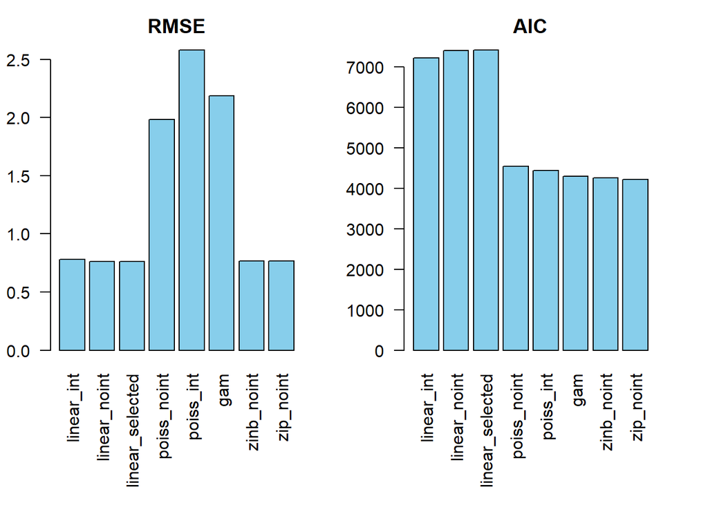

```r
values <- list(error_metrics.linear_int, error_metrics.linear_noint, error_metrics.linear_selected ,error_metrics.poiss_noint, error_metrics.poiss_int, error_metrics.gam, error_metrics.zip_noint, error_metrics.zinb_noint)

RMSE_list = list()
AIC_list = list()

for (i in values) {
  RMSE_list <- c(append(RMSE_list, i$RMSE))
  AIC_list <- c(append(AIC_list, i$AIC))
}

model_names = c("linear_int","linear_noint","linear_selected", "poiss_noint", "poiss_int", "gam", "zinb_noint", "zip_noint")

metrics_df <- data.frame(
  Model = model_names,
  RMSE = unlist(RMSE_list),
  AIC = unlist(AIC_list)
)

par(mfrow=c(1,2), mai=c(1.5,0.5,0.5,0.5))
barplot(unlist(RMSE_list), main = "RMSE", col = "skyblue", las=2 ,names = metrics_df$Model)
barplot(unlist(AIC_list), main = "AIC", col = "skyblue", las=2 ,names = metrics_df$Model)
```

```r
par(mfrow=c(1,1))
```

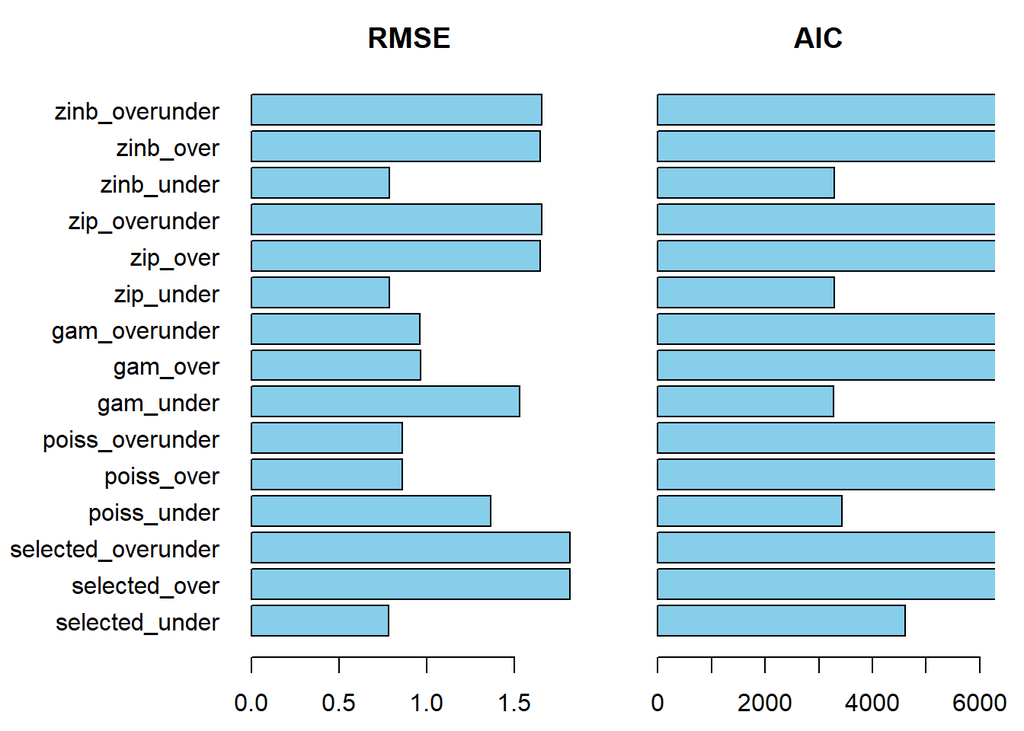

```r
values_new_dataset <- list(error_metrics.selected_under, error_metrics.selected_over, error_metrics.selected_overunder, error_metrics.poiss_under, error_metrics.poiss_over, error_metrics.poiss_overunder, error_metrics.gam_under, error_metrics.gam_over,
error_metrics.gam_overunder, error_metrics.zip_under, error_metrics.zip_over,error_metrics.zip_overunder, error_metrics.zinb_under, error_metrics.zinb_over, error_metrics.zinb_overunder)

RMSE_list_newdata = list()
AIC_list_newdata = list()

for (i in values_new_dataset) {
  RMSE_list_newdata <- c(append(RMSE_list_newdata, i$RMSE))
  AIC_list_newdata <- c(append(AIC_list_newdata, i$AIC))
}

model_names_newdata = c("selected_under","selected_over","selected_overunder", "poiss_under", "poiss_over", "poiss_overunder", "gam_under", "gam_over", "gam_overunder","zip_under", "zip_over", "zip_overunder", "zinb_under", "zinb_over", "zinb_overunder")

metrics_df_newdata <- data.frame(
  Model = model_names_newdata,
  RMSE = unlist(RMSE_list_newdata),
  AIC = unlist(AIC_list_newdata)
)

par(mfrow=c(1,2), mai=c(0.5,0.5,0.5,0.1), oma=c(0,6,0,1))
barplot(unlist(RMSE_list_newdata), main = "RMSE", col = "skyblue", las=1, horiz=T, names = metrics_df_newdata$Model)
barplot(unlist(AIC_list_newdata), main = "AIC", col = "skyblue", las=1, horiz=T, xlim=c(0,6000))
```

```r
par(mfrow=c(1,1))
```

### Classification

Since the `doctorco` variable counts the visits in the previous 2 weeks, we thought that it may also be interesting to predict, based on the variables, $0$ visits or $>0$ visits: binary classification. Like before, we will fit one with all the variables with no interaction and one with interaction.

```r
df_binary_classification = train_data
df_binary_classification$doctorco <- ifelse(df_binary_classification$doctorco > 0, 1, 0)
df_binary_classification$doctorco <- factor(df_binary_classification$doctorco, levels = c(0,1), labels = c("No", "One or more"))
```

```r
df_binary_classification_test = test_data
df_binary_classification_test$doctorco <- ifelse(df_binary_classification_test$doctorco > 0, 1, 0)
df_binary_classification_test$doctorco <- factor(df_binary_classification_test$doctorco, levels = c(0,1), labels = c("No", "One or more"))
```

```r
model.logit_noint <- glm(doctorco ~ ., data = df_binary_classification, family = binomial)
summary(model.logit_noint)
```

```
##
## Call:
## glm(formula = doctorco ~ ., family = binomial, data = df_binary_classification)
##
## Coefficients:
##                    Estimate Std. Error z value Pr(>|z|)
## (Intercept)       -2.357101   0.179001 -13.168  < 2e-16 ***
## sexFemale          0.190113   0.100872   1.885  0.05947 .
## age               -0.309855   0.315484  -0.982  0.32602
## income            -0.018912   0.147805  -0.128  0.89819
## illness            0.151660   0.036892   4.111 3.94e-05 ***
## actdays            0.153132   0.015625   9.801  < 2e-16 ***
## hscore             0.061242   0.021303   2.875  0.00404 **
## nondocco           0.021980   0.041906   0.525  0.59993
## hospadmi           0.135960   0.099173   1.371  0.17040
## hospdays           0.001175   0.006858   0.171  0.86391
## prescrib           0.307426   0.036786   8.357  < 2e-16 ***
## nonpresc          -0.146063   0.066379  -2.200  0.02778 *
## insurancePrivate   0.217327   0.121604   1.787  0.07391 .
## insuranceFreepoor -0.653375   0.315524  -2.071  0.03838 *
## insuranceFreepera  0.410057   0.171842   2.386  0.01702 *
## chcondNot-limited  0.076999   0.112030   0.687  0.49189
## chcondLimited     -0.046674   0.162184  -0.288  0.77351
## ---
## Signif. codes:  0 '***' 0.001 '**' 0.01 '*' 0.05 '.' 0.1 ' ' 1
##
## (Dispersion parameter for binomial family taken to be 1)
##
##     Null deviance: 3656.3  on 3632  degrees of freedom
## Residual deviance: 3109.7  on 3616  degrees of freedom
## AIC: 3143.7
##
## Number of Fisher Scoring iterations: 5
```

```r
model.logit_int <- glm(doctorco ~ (.)^2, data = df_binary_classification, family = binomial)
summary(model.logit_int)
```

```
##
## Call:
## glm(formula = doctorco ~ (.)^2, family = binomial, data = df_binary_classification)
##
## Coefficients:
##                                       Estimate Std. Error z value Pr(>|z|)
## (Intercept)                         -3.072e+00  4.789e-01  -6.415 1.41e-10 ***
## sexFemale                            5.363e-01  3.983e-01   1.346 0.178179
## age                                  1.750e+00  1.257e+00   1.392 0.163784
## income                              -1.546e-01  5.215e-01  -0.296 0.766862
## illness                              5.175e-01  1.668e-01   3.103 0.001918 **
## actdays                              4.299e-01  7.704e-02   5.580 2.41e-08 ***
## hscore                               8.361e-02  9.306e-02   0.898 0.368956
## nondocco                             9.843e-02  2.669e-01   0.369 0.712310
## hospadmi                            -7.728e-02  5.037e-01  -0.153 0.878072
## hospdays                            -2.305e-04  5.207e-02  -0.004 0.996467
## prescrib                             1.216e+00  2.256e-01   5.391 7.01e-08 ***
## nonpresc                            -2.869e-01  3.032e-01  -0.946 0.344163
## insurancePrivate                    -3.696e-01  4.998e-01  -0.739 0.459625
## insuranceFreepoor                   -2.879e-01  1.995e+00  -0.144 0.885264
## insuranceFreepera                   -5.142e-01  9.491e-01  -0.542 0.587930
## chcondNot-limited                   -9.407e-01  5.136e-01  -1.832 0.067023 .
## chcondLimited                       -1.182e+00  7.962e-01  -1.484 0.137814
## sexFemale:age                       -1.547e+00  7.724e-01  -2.003 0.045153 *
## sexFemale:income                    -1.007e-01  3.399e-01  -0.296 0.767035
## sexFemale:illness                   -9.562e-04  8.647e-02  -0.011 0.991177
## sexFemale:actdays                   -1.934e-02  3.803e-02  -0.508 0.611119
## sexFemale:hscore                    -1.036e-01  5.398e-02  -1.918 0.055054 .
## sexFemale:nondocco                  -2.737e-03  1.193e-01  -0.023 0.981698
## sexFemale:hospadmi                  -1.214e-01  2.601e-01  -0.467 0.640551
## sexFemale:hospdays                   2.038e-02  2.004e-02   1.017 0.309001
## sexFemale:prescrib                   8.577e-02  8.614e-02   0.996 0.319445
## sexFemale:nonpresc                   3.677e-02  1.652e-01   0.223 0.823863
## sexFemale:insurancePrivate           4.889e-01  2.943e-01   1.661 0.096640 .
## sexFemale:insuranceFreepoor          1.355e+00  1.047e+00   1.294 0.195605
## sexFemale:insuranceFreepera          3.725e-01  4.102e-01   0.908 0.363804
## sexFemale:chcondNot-limited         -7.868e-02  2.678e-01  -0.294 0.768907
## sexFemale:chcondLimited             -7.666e-02  3.761e-01  -0.204 0.838507
## age:income                          -3.087e+00  1.161e+00  -2.659 0.007835 **
## age:illness                         -3.686e-01  2.841e-01  -1.297 0.194475
```

[output cut: 94 more lines]

```
## insuranceFreepoor:chcondNot-limited  2.799e+00  1.156e+00   2.422 0.015444 *
## insuranceFreepera:chcondNot-limited  4.684e-01  4.848e-01   0.966 0.333926
## insurancePrivate:chcondLimited       9.446e-01  5.377e-01   1.757 0.078939 .
## insuranceFreepoor:chcondLimited      1.551e+00  1.615e+00   0.960 0.336825
## insuranceFreepera:chcondLimited      1.375e+00  6.758e-01   2.035 0.041832 *
## ---
## Signif. codes:  0 '***' 0.001 '**' 0.01 '*' 0.05 '.' 0.1 ' ' 1
##
## (Dispersion parameter for binomial family taken to be 1)
##
##     Null deviance: 3656.3  on 3632  degrees of freedom
## Residual deviance: 2859.6  on 3500  degrees of freedom
## AIC: 3125.6
##
## Number of Fisher Scoring iterations: 15
```

And let’s finally check the predictive power of this model

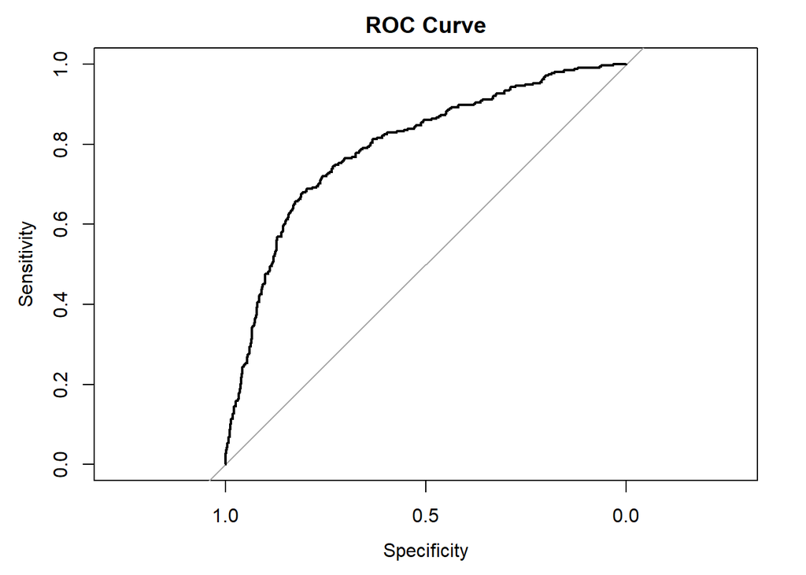

```r
predictions_prob_noint <- predict(model.logit_noint, newdata = df_binary_classification_test, type = "response")
predictions_noint <- ifelse(predictions_prob_noint > 0.5, 1, 0)

roc_curve_noint <- roc(df_binary_classification_test$doctorco, predictions_prob_noint)
plot(roc_curve_noint, main = "ROC Curve")
```

```r
print(auc(roc_curve_noint))
```

```
## Area under the curve: 0.7918
```

```r
predictions_noint <- factor(predictions_noint, levels = c(0, 1), labels = c("No", "One or more"))
conf_matrix <- confusionMatrix(predictions_noint, df_binary_classification_test$doctorco)
conf_matrix
```

```
## Confusion Matrix and Statistics
##
##              Reference
## Prediction      No One or more
##   No          1189         239
##   One or more   53          76
##
##                Accuracy : 0.8125
##                  95% CI : (0.7922, 0.8316)
##     No Information Rate : 0.7977
##     P-Value [Acc > NIR] : 0.07692
##
##                   Kappa : 0.2547
##
##  Mcnemar's Test P-Value : < 2e-16
##
##             Sensitivity : 0.9573
##             Specificity : 0.2413
##          Pos Pred Value : 0.8326
##          Neg Pred Value : 0.5891
##              Prevalence : 0.7977
##          Detection Rate : 0.7636
##    Detection Prevalence : 0.9171
##       Balanced Accuracy : 0.5993
##
##        'Positive' Class : No
##
```

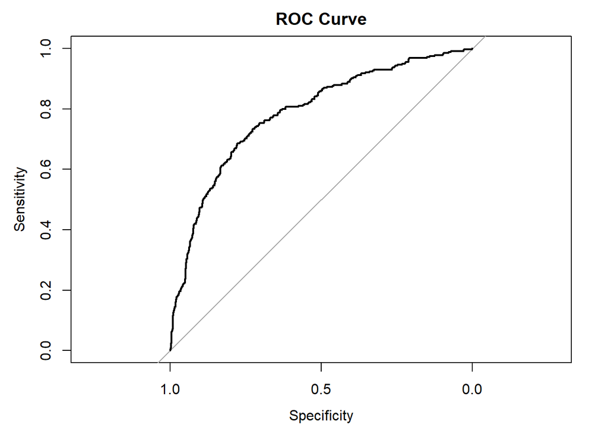

```r
predictions_prob_int <- predict(model.logit_int, newdata = df_binary_classification_test, type = "response")
predictions_int <- ifelse(predictions_prob_int > 0.5, 1, 0)

roc_curve_int <- roc(df_binary_classification_test$doctorco, predictions_prob_int)
plot(roc_curve_int, main = "ROC Curve")
```

```r
print(auc(roc_curve_int))
```

```
## Area under the curve: 0.7844
```

```r
predictions_int <- factor(predictions_int, levels = c(0, 1), labels = c("No", "One or more"))
conf_matrix_int <- confusionMatrix(predictions_int, df_binary_classification_test$doctorco)
conf_matrix_int
```

```
## Confusion Matrix and Statistics
##
##              Reference
## Prediction      No One or more
##   No          1175         221
##   One or more   67          94
##
##                Accuracy : 0.815
##                  95% CI : (0.7948, 0.834)
##     No Information Rate : 0.7977
##     P-Value [Acc > NIR] : 0.04613
##
##                   Kappa : 0.299
##
##  Mcnemar's Test P-Value : < 2e-16
##
##             Sensitivity : 0.9461
##             Specificity : 0.2984
##          Pos Pred Value : 0.8417
##          Neg Pred Value : 0.5839
##              Prevalence : 0.7977
##          Detection Rate : 0.7547
##    Detection Prevalence : 0.8966
##       Balanced Accuracy : 0.6222
##
##        'Positive' Class : No
##
```